# Laboratory 2 - Model Engineering

```
================================================================================
Confusion matrices for ALL Simple RNN learning rates - VALIDATION
================================================================================

Generating confusion matrix for Simple RNN with lr=2e-04...
Saved plot: /content/drive/MyDrive/Projects/AImSecure/Laboratory2/results/images/task3_plots/cm_simple_rnn_(lr=2e_04).png
```

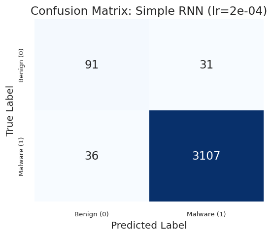

```
Generating confusion matrix for Simple RNN with lr=1e-04...
Saved plot: /content/drive/MyDrive/Projects/AImSecure/Laboratory2/results/images/task3_plots/cm_simple_rnn_(lr=1e_04).png
```

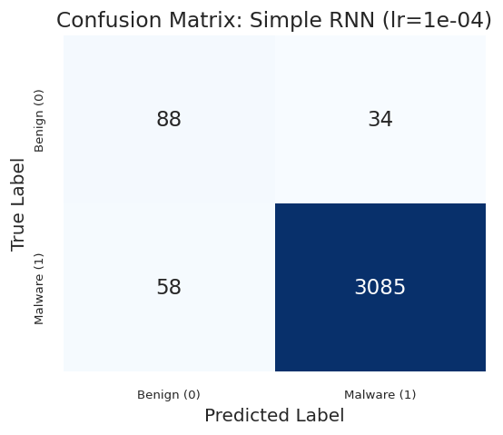

```
Generating confusion matrix for Simple RNN with lr=8e-05...
Saved plot: /content/drive/MyDrive/Projects/AImSecure/Laboratory2/results/images/task3_plots/cm_simple_rnn_(lr=8e_05).png
```

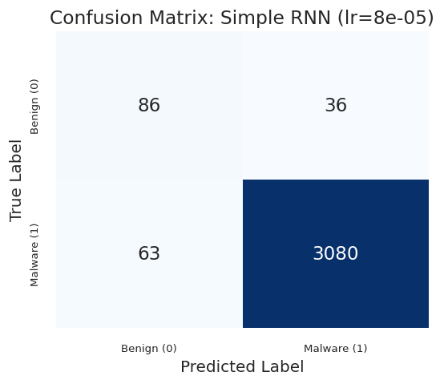

```
Generating confusion matrix for Simple RNN with lr=5e-05...
Saved plot: /content/drive/MyDrive/Projects/AImSecure/Laboratory2/results/images/task3_plots/cm_simple_rnn_(lr=5e_05).png
```

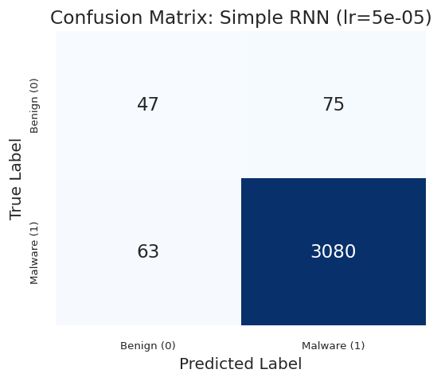

```python
# --- Plot confusion matrices for ALL learning rates - VALIDATION ---

print("\n" + "=" * 80)
print("Confusion matrices for ALL Simple RNN learning rates - VALIDATION")
print("=" * 80)

for lr in learning_rates:
    model = models_simple[lr]
    print(f"\nGenerating confusion matrix for Simple RNN with lr={lr:.0e}...")

    plot_cm_task3(model=model, loader=val_loader, model_name=f"Simple RNN (lr={lr:.0e})", save_dir=save_dir)
```

```
================================================================================
Confusion matrices for ALL Simple RNN learning rates - TEST
================================================================================

Generating confusion matrix for Simple RNN with lr=2e-04...
Saved plot: /content/drive/MyDrive/Projects/AImSecure/Laboratory2/results/images/task3_plots/cm_simple_rnn_(lr=2e_04).png
```

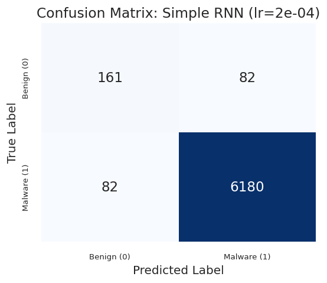

```
Generating confusion matrix for Simple RNN with lr=1e-04...
Saved plot: /content/drive/MyDrive/Projects/AImSecure/Laboratory2/results/images/task3_plots/cm_simple_rnn_(lr=1e_04).png
```

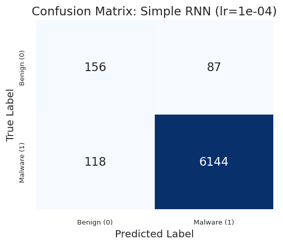

```
Generating confusion matrix for Simple RNN with lr=8e-05...
Saved plot: /content/drive/MyDrive/Projects/AImSecure/Laboratory2/results/images/task3_plots/cm_simple_rnn_(lr=8e_05).png
```

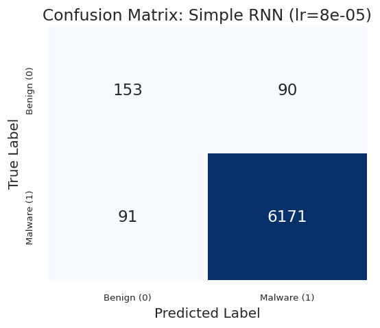

```
Generating confusion matrix for Simple RNN with lr=5e-05...
Saved plot: /content/drive/MyDrive/Projects/AImSecure/Laboratory2/results/images/task3_plots/cm_simple_rnn_(lr=5e_05).png
```

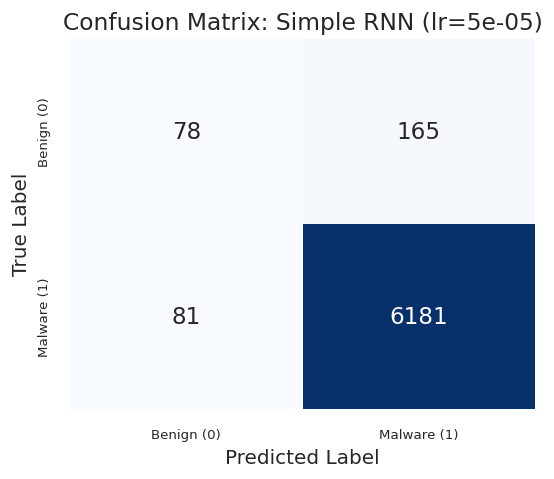

```python
# --- Plot confusion matrices for ALL learning rates - TEST ---

print("\n" + "=" * 80)
print("Confusion matrices for ALL Simple RNN learning rates - TEST")
print("=" * 80)

for lr in learning_rates:
    model = models_simple[lr]
    print(f"\nGenerating confusion matrix for Simple RNN with lr={lr:.0e}...")

    plot_cm_task3(model=model, loader=test_loader, model_name=f"Simple RNN (lr={lr:.0e})", save_dir=save_dir)
```

#### Q: Start with a simple one-directional RNN. Is your network as fast as the FFNN? If not, why?

No. The simple one-directional RNN is clearly slower than the FFNN models. In this run, the selected FFNN with sequential IDs trained in about `32` seconds, the selected FFNN with learnable embeddings in about `33` seconds, while the selected Simple RNN required about `5 min 19 s`.

The main reason is the sequential dependency across time steps. An FFNN processes the whole fixed-length input vector through dense matrix operations, which are highly parallelizable. An RNN instead updates its hidden state step by step, and each step depends on the previous hidden state. This limits parallelization across the temporal dimension.

Training is also more expensive because backpropagation through time must propagate gradients through the entire sequence, and the data loader performs sorting, dynamic padding, and packed-sequence handling. Even though packing avoids wasted computation on padding tokens, the recurrent structure remains substantially slower than the FFNN.

### Network Variations

```python
# --- Variation 2: Bidirectional RNN ---

print("\n" + "=" * 80)
print("Training Bidirectional RNN with different learning rates")
print("=" * 80)

# Shared protocol for the bidirectional vanilla RNN and bidirectional LSTM
COMMON_RNN_LEARNING_RATES = [5e-5, 8e-5, 1e-4, 1.5e-4, 2e-4, 3e-4]
COMMON_RNN_DROPOUT = 0.3
COMMON_RNN_WEIGHT_DECAY = 1e-4
COMMON_RNN_PATIENCE = 25
COMMON_RNN_SEED = 42
COMMON_RNN_SCHEDULER = {
    'mode': 'min',
    'factor': 0.5,
    'patience': 7,
    'min_lr': 1e-7,
}

learning_rates_bi = COMMON_RNN_LEARNING_RATES

# Model parameters
bi_rnn_params = {
    'vocab_size': vocab_size_rnn,
    'embed_dim': 32,
    'hidden_size': 128,
    'num_layers': 2,
    'num_classes': 1,
    'bidirectional': True,
    'dropout': COMMON_RNN_DROPOUT
}

# Initialize early stopping parameters
min_delta = 0.00001
patience = COMMON_RNN_PATIENCE

# Scheduler parameters
scheduler_params_bi = COMMON_RNN_SCHEDULER.copy()

# Store histories and models for each LR
histories_bi = {}
models_bi = {}
elapsed_bi = {}

for lr in learning_rates_bi:
    print(f"\n--- Training Bi-RNN with lr={lr:.0e} ---")
    model, history, elapsed = train_with_lr(
        model_class=SimpleRNNClassifier,
        model_params=bi_rnn_params,
        initial_lr=lr,
        train_loader=train_loader,
        val_loader=val_loader,
        criterion=nn.BCEWithLogitsLoss(pos_weight=pos_weight),
        num_epochs=num_epochs,
        min_delta=min_delta,
        patience=patience,
        scheduler_params=scheduler_params_bi,
        device=device,
        weight_decay=COMMON_RNN_WEIGHT_DECAY,
        seed=COMMON_RNN_SEED,
    )
    histories_bi[lr] = history
    models_bi[lr] = model
    elapsed_bi[lr] = elapsed
    elapsed_str = time.strftime('%H:%M:%S', time.gmtime(elapsed))
    print(f"Completed. Training time: {elapsed_str} ({elapsed:.2f}s) - Final val loss: {history['val_loss'][-1]:.4f}")
```

```
================================================================================
Training Bidirectional RNN with different learning rates
================================================================================

--- Training Bi-RNN with lr=5e-05 ---
Epoch 14: LR reduced from 0.000050 to 0.000025
Epoch 36: LR reduced from 0.000025 to 0.000013
Epoch 44: LR reduced from 0.000013 to 0.000006
Epoch 52: LR reduced from 0.000006 to 0.000003
Early stopping at epoch 55 (best val macro F1 0.7016 at epoch 30, val loss 0.074918)
Completed. Training time: 00:03:49 (229.17s) - Final val loss: 0.0746

--- Training Bi-RNN with lr=8e-05 ---
Epoch 36: LR reduced from 0.000080 to 0.000040
Epoch 55: LR reduced from 0.000040 to 0.000020
Epoch 63: LR reduced from 0.000020 to 0.000010
Early stopping at epoch 69 (best val macro F1 0.7817 at epoch 44, val loss 0.053858)
Completed. Training time: 00:04:43 (283.64s) - Final val loss: 0.0540

--- Training Bi-RNN with lr=1e-04 ---
Epoch 36: LR reduced from 0.000100 to 0.000050
Epoch 59: LR reduced from 0.000050 to 0.000025
Epoch 67: LR reduced from 0.000025 to 0.000013
Early stopping at epoch 69 (best val macro F1 0.7939 at epoch 44, val loss 0.052390)
Completed. Training time: 00:04:45 (285.20s) - Final val loss: 0.0568

--- Training Bi-RNN with lr=1e-04 ---
Epoch 36: LR reduced from 0.000150 to 0.000075
Epoch 69: LR reduced from 0.000075 to 0.000037
Epoch 77: LR reduced from 0.000037 to 0.000019
Epoch 90: LR reduced from 0.000019 to 0.000009
Epoch 98: LR reduced from 0.000009 to 0.000005
Epoch 106: LR reduced from 0.000005 to 0.000002
Epoch 114: LR reduced from 0.000002 to 0.000001
Early stopping at epoch 120 (best val macro F1 0.8222 at epoch 95, val loss 0.049792)
Completed. Training time: 00:08:09 (489.39s) - Final val loss: 0.0516

--- Training Bi-RNN with lr=2e-04 ---
Epoch 16: LR reduced from 0.000200 to 0.000100
Epoch 36: LR reduced from 0.000100 to 0.000050
Epoch 46: LR reduced from 0.000050 to 0.000025
Early stopping at epoch 59 (best val macro F1 0.7893 at epoch 34, val loss 0.054008)
Completed. Training time: 00:03:58 (238.96s) - Final val loss: 0.0525

--- Training Bi-RNN with lr=3e-04 ---
Epoch 44: LR reduced from 0.000300 to 0.000150
Epoch 54: LR reduced from 0.000150 to 0.000075
Epoch 62: LR reduced from 0.000075 to 0.000037
Epoch 70: LR reduced from 0.000037 to 0.000019
Epoch 78: LR reduced from 0.000019 to 0.000009
Epoch 86: LR reduced from 0.000009 to 0.000005
Epoch 94: LR reduced from 0.000005 to 0.000002
Early stopping at epoch 100 (best val macro F1 0.8198 at epoch 75, val loss 0.068449)
Completed. Training time: 00:06:50 (410.33s) - Final val loss: 0.0730
```

```
Saved plot: /content/drive/MyDrive/Projects/AImSecure/Laboratory2/results/images/task3_plots/bidirectional_rnn_lr_comparison.png
```

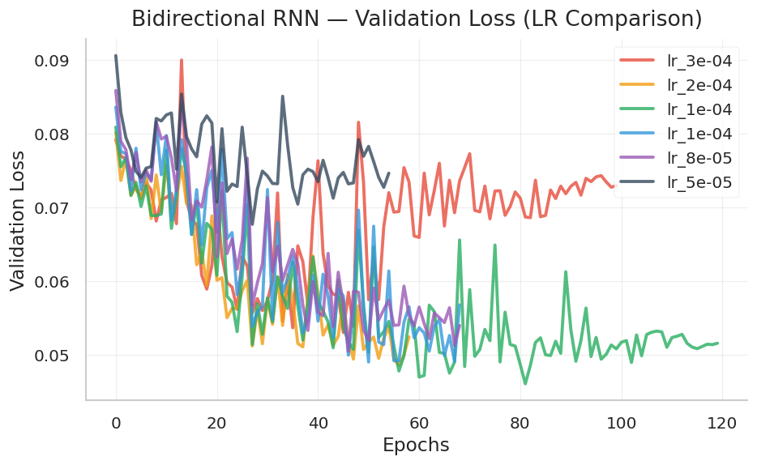

```
Saved plot: /content/drive/MyDrive/Projects/AImSecure/Laboratory2/results/images/task3_plots/bidirectional_rnn_diagnosis.png
```

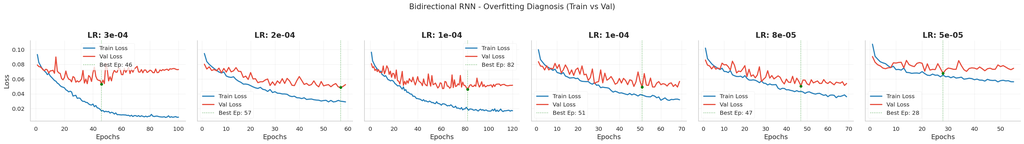

```python
# --- Plot loss curves ---

# Plot comparison
plot_lr_comparison(histories_bi, "Bidirectional RNN", save_dir)

#Plot Train vs Validation
plot_train_val_grid(histories_bi, "Bidirectional RNN", save_dir)
```

```
Saved plot: /content/drive/MyDrive/Projects/AImSecure/Laboratory2/results/images/task3_plots/bidirectional_rnn_f1_comparison.png
```

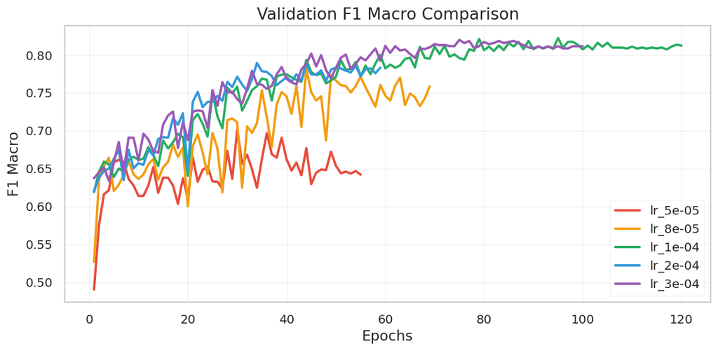

```python
# --- Plot Validation F1 Macro for Bidirectional RNN ---
plot_training_metrics(histories_bi, save_dir=save_dir, plot_name="bidirectional_rnn_f1_comparison")
```

```python
# --- Evaluate validation and test sets for ALL learning rates ---

print("\n" + "=" * 80)
print("Evaluation for ALL Bi-RNN learning rates")
print("=" * 80)

for lr in learning_rates_bi:
    model = models_bi[lr]

    print(f"\n{'='*60}")
    print(f"Bi-RNN with lr={lr:.0e}")
    print(f"{'='*60}")

    # Validation evaluation
    y_val_true, y_val_pred = predict_loader(model, val_loader)
    print(f'\nValidation report (Bi-RNN - lr={lr:.0e}):')
    print(classification_report(y_val_true, y_val_pred, digits=4, zero_division=0))

    # Test evaluation
    y_test_true, y_test_pred = predict_loader(model, test_loader)
    print(f'Test report (Bi-RNN - lr={lr:.0e}):')
    print(classification_report(y_test_true, y_test_pred, digits=4, zero_division=0))

# Select the restored model using validation metrics only
best_bi_lr_value, bi_selection_table = select_best_rnn_model(
    'Bidirectional RNN', models_bi, histories_bi, val_loader
)
best_lr_bi = (best_bi_lr_value, histories_bi[best_bi_lr_value])
print(f"\n{'='*60}")
print(
    f"Best Bi-RNN - LR: {best_lr_bi[0]:.0e} "
    f"(Val Macro F1: {bi_selection_table.loc[0, 'val_macro_f1']:.4f})"
)
print(f"{'='*60}")
```

```
================================================================================
Evaluation for ALL Bi-RNN learning rates
================================================================================

============================================================
Bi-RNN with lr=5e-05
============================================================

Validation report (Bi-RNN - lr=5e-05):
              precision    recall  f1-score   support

           0     0.4700    0.3852    0.4234       122
           1     0.9763    0.9831    0.9797      3143

    accuracy                         0.9608      3265
   macro avg     0.7232    0.6842    0.7016      3265
weighted avg     0.9574    0.9608    0.9589      3265

Test report (Bi-RNN - lr=5e-05):
              precision    recall  f1-score   support

           0     0.4467    0.3621    0.4000       243
           1     0.9754    0.9826    0.9790      6262

    accuracy                         0.9594      6505
   macro avg     0.7111    0.6724    0.6895      6505
weighted avg     0.9557    0.9594    0.9574      6505


============================================================
Bi-RNN with lr=8e-05
============================================================

Validation report (Bi-RNN - lr=8e-05):
              precision    recall  f1-score   support

           0     0.5564    0.6066    0.5804       122
           1     0.9847    0.9812    0.9829      3143

    accuracy                         0.9672      3265
```

[output cut: 113 more lines]

```

Automatic selection for Bidirectional RNN
Ranking criterion: validation macro F1, then validation accuracy, then checkpoint validation loss
 learning_rate  val_macro_f1  val_accuracy  checkpoint_val_loss  checkpoint_epoch
       0.00015      0.822150      0.970904             0.049792                95
       0.00030      0.819765      0.973354             0.068449                75
       0.00010      0.793913      0.969066             0.052390                44
       0.00020      0.789254      0.967534             0.054008                34
       0.00008      0.781670      0.967228             0.053858                44
       0.00005      0.701566      0.960796             0.074918                30
Selected Bidirectional RNN: lr=1e-04, validation macro F1=0.8222, checkpoint epoch=95

============================================================
Best Bi-RNN - LR: 1e-04 (Val Macro F1: 0.8222)
============================================================
```

```
================================================================================
Confusion matrices for ALL Bi-RNN learning rates - VALIDATION
================================================================================

Generating confusion matrix for Bi-RNN with lr=5e-05...
Saved plot: /content/drive/MyDrive/Projects/AImSecure/Laboratory2/results/images/task3_plots/cm_bi_rnn_(lr=5e_05).png
```

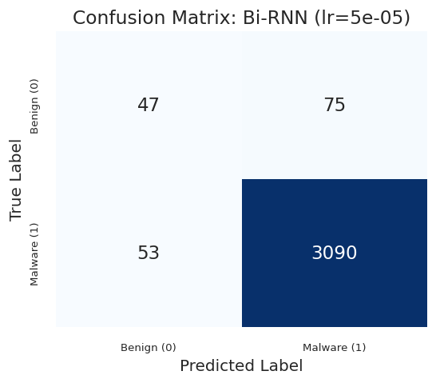

```
Generating confusion matrix for Bi-RNN with lr=8e-05...
Saved plot: /content/drive/MyDrive/Projects/AImSecure/Laboratory2/results/images/task3_plots/cm_bi_rnn_(lr=8e_05).png
```

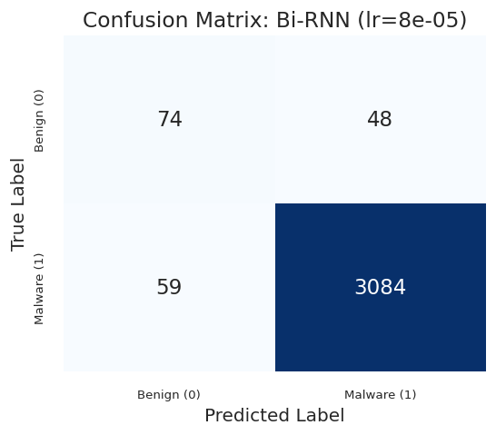

```
Generating confusion matrix for Bi-RNN with lr=1e-04...
Saved plot: /content/drive/MyDrive/Projects/AImSecure/Laboratory2/results/images/task3_plots/cm_bi_rnn_(lr=1e_04).png
```

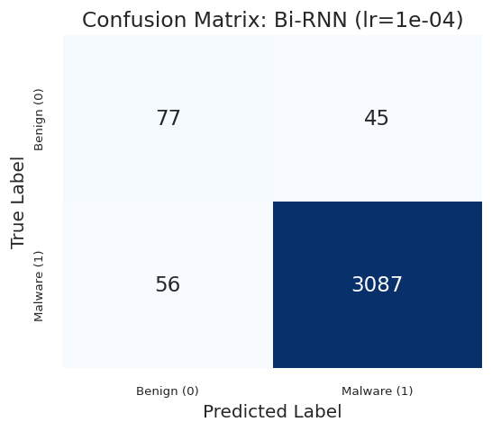

```
Generating confusion matrix for Bi-RNN with lr=1e-04...
Saved plot: /content/drive/MyDrive/Projects/AImSecure/Laboratory2/results/images/task3_plots/cm_bi_rnn_(lr=1e_04).png
```

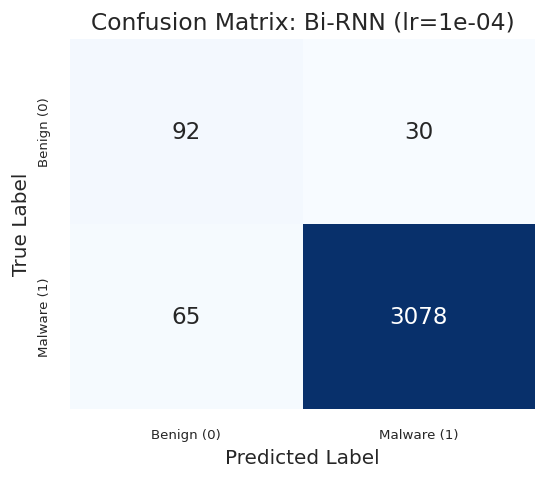

```
Generating confusion matrix for Bi-RNN with lr=2e-04...
Saved plot: /content/drive/MyDrive/Projects/AImSecure/Laboratory2/results/images/task3_plots/cm_bi_rnn_(lr=2e_04).png
```

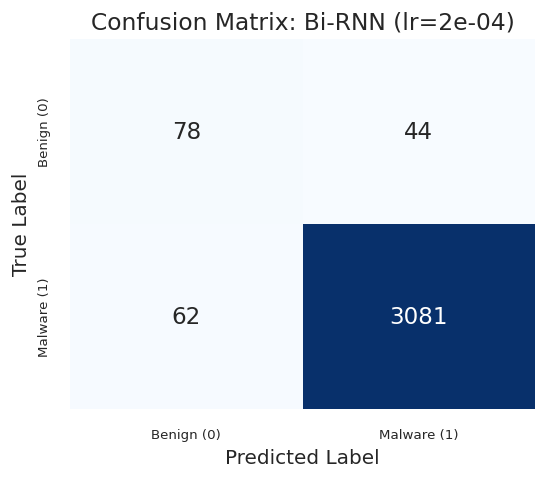

```
Generating confusion matrix for Bi-RNN with lr=3e-04...
Saved plot: /content/drive/MyDrive/Projects/AImSecure/Laboratory2/results/images/task3_plots/cm_bi_rnn_(lr=3e_04).png
```

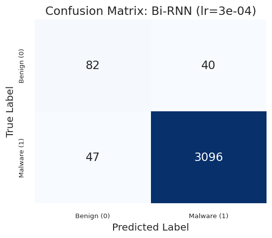

```python
# --- Plot confusion matrices for ALL learning rates - VALIDATION ---

print("\n" + "=" * 80)
print("Confusion matrices for ALL Bi-RNN learning rates - VALIDATION")
print("=" * 80)

for lr in learning_rates_bi:
    model = models_bi[lr]
    print(f"\nGenerating confusion matrix for Bi-RNN with lr={lr:.0e}...")

    plot_cm_task3(model=model, loader=val_loader, model_name=f"Bi-RNN (lr={lr:.0e})", save_dir=save_dir)
```

```
================================================================================
Confusion matrices for ALL Bi-RNN learning rates - TEST
================================================================================

Generating confusion matrix for Bi-RNN with lr=5e-05...
Saved plot: /content/drive/MyDrive/Projects/AImSecure/Laboratory2/results/images/task3_plots/cm_bi_rnn_(lr=5e_05).png
```

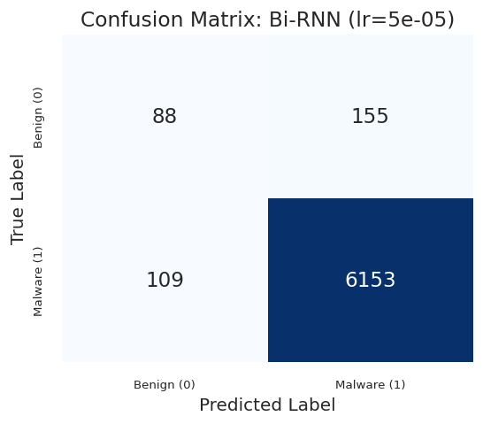

```
Generating confusion matrix for Bi-RNN with lr=8e-05...
Saved plot: /content/drive/MyDrive/Projects/AImSecure/Laboratory2/results/images/task3_plots/cm_bi_rnn_(lr=8e_05).png
```

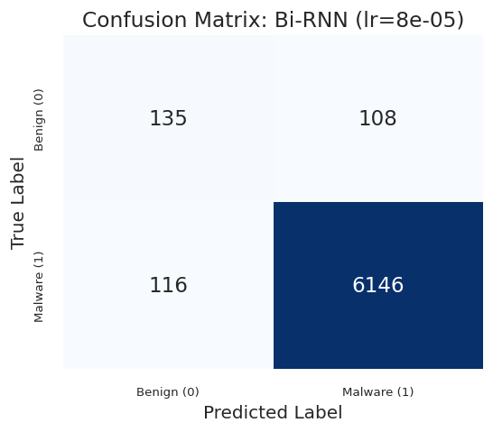

```
Generating confusion matrix for Bi-RNN with lr=1e-04...
Saved plot: /content/drive/MyDrive/Projects/AImSecure/Laboratory2/results/images/task3_plots/cm_bi_rnn_(lr=1e_04).png
```

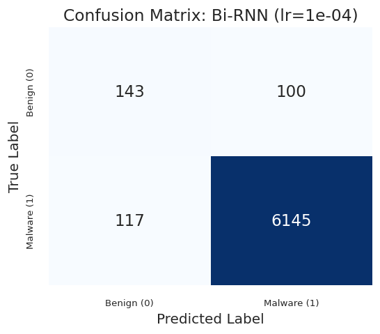

```
Generating confusion matrix for Bi-RNN with lr=1e-04...
Saved plot: /content/drive/MyDrive/Projects/AImSecure/Laboratory2/results/images/task3_plots/cm_bi_rnn_(lr=1e_04).png
```

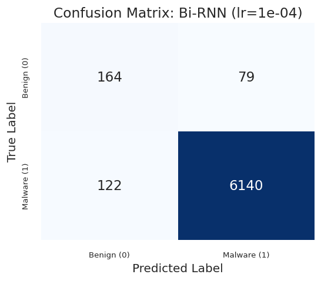

```
Generating confusion matrix for Bi-RNN with lr=2e-04...
Saved plot: /content/drive/MyDrive/Projects/AImSecure/Laboratory2/results/images/task3_plots/cm_bi_rnn_(lr=2e_04).png
```

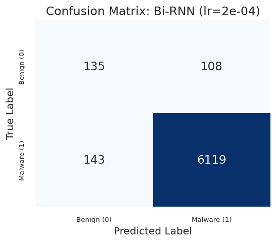

```
Generating confusion matrix for Bi-RNN with lr=3e-04...
Saved plot: /content/drive/MyDrive/Projects/AImSecure/Laboratory2/results/images/task3_plots/cm_bi_rnn_(lr=3e_04).png
```

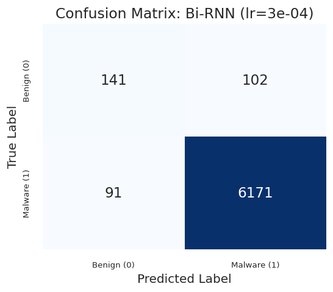

```python
# --- Plot confusion matrices for ALL learning rates - TEST ---

print("\n" + "=" * 80)
print("Confusion matrices for ALL Bi-RNN learning rates - TEST")
print("=" * 80)

for lr in learning_rates_bi:
    model = models_bi[lr]
    print(f"\nGenerating confusion matrix for Bi-RNN with lr={lr:.0e}...")

    plot_cm_task3(model=model, loader=test_loader, model_name=f"Bi-RNN (lr={lr:.0e})", save_dir=save_dir)
```

```python
# --- Variation 3: LSTM (bidirectional) ---

class LSTMClassifier(nn.Module):
    def __init__(self, vocab_size, embed_dim=32, hidden_size=128, num_layers=2, num_classes=1, bidirectional=True, dropout=0.3, padding=0):
        super(LSTMClassifier, self).__init__()

        # Embedding layer: Maps API call indices to dense vectors. padding_idx is set.
        self.embedding = nn.Embedding(vocab_size, embedding_dim=embed_dim, padding_idx=padding)

        # LSTM layer: A more complex RNN unit that helps prevent vanishing gradients.
        # batch_first=True expects input shape (batch_size, seq_len, features).
        self.lstm = nn.LSTM(
            input_size=embed_dim,
            hidden_size=hidden_size,
            num_layers=num_layers,
            batch_first=True,
            bidirectional=bidirectional,
            dropout=dropout if num_layers > 1 else 0.0,
        )

        self.bidirectional = bidirectional
        fc_in = hidden_size * (2 if bidirectional else 1)

        self.fc = nn.Linear(fc_in, num_classes)
        self.dropout = nn.Dropout(dropout)

    def forward(self, x, lengths):
        # Embed the input indices
        emb = self.embedding(x) # (batch_size, max_seq_len, embed_dim)
        emb = self.dropout(emb)

        # Pack the padded sequence to efficiently process variable lengths
        packed = pack_padded_sequence(emb, lengths.cpu(), batch_first=True, enforce_sorted=True)

        # LSTM returns packed_output, (final_hidden_state, final_cell_state)
        packed_out, (hn, cn) = self.lstm(packed)

        # hn shape: (num_layers * num_directions, batch_size, hidden_size)

        # Get the final hidden state from the last layer
        if self.bidirectional:
            # Concatenate the final forward state (hn[-2]) and backward state (hn[-1])
            h_last = torch.cat([hn[-2], hn[-1]], dim=1)
        else:
            # Use the final hidden state of the last layer (hn[-1])
            h_last = hn[-1]

        # Pass the final hidden state through the classifier
        out = self.fc(h_last)
        return out
```

```python
# --- Variation 3: LSTM (bidirectional) ---

print("\n" + "=" * 80)
print("Training LSTM with different learning rates")
print("=" * 80)

# Model parameters
lstm_params = {
    'vocab_size': vocab_size_rnn,
    'embed_dim': 32,
    'hidden_size': 128,
    'num_layers': 2,
    'num_classes': 1,
    'bidirectional': True,
    'dropout': COMMON_RNN_DROPOUT
}

# Initialize early stopping parameters
min_delta = 0.00001
patience = COMMON_RNN_PATIENCE

# Scheduler parameters
scheduler_params_lstm = COMMON_RNN_SCHEDULER.copy()

# Use the same learning-rate grid as the bidirectional vanilla RNN
learning_rates_lstm = COMMON_RNN_LEARNING_RATES

# Store histories and models for each LR
histories_lstm = {}
models_lstm = {}
elapsed_lstm = {}

for lr in learning_rates_lstm:
    print(f"\n--- Training LSTM with lr={lr:.0e} ---")
    model, history, elapsed = train_with_lr(
        model_class=LSTMClassifier,
        model_params=lstm_params,
        initial_lr=lr,
        train_loader=train_loader,
        val_loader=val_loader,
        criterion=nn.BCEWithLogitsLoss(pos_weight=pos_weight),
        num_epochs=num_epochs,
        min_delta=min_delta,
        patience=patience,
        scheduler_params=scheduler_params_lstm,
        device=device,
        weight_decay=COMMON_RNN_WEIGHT_DECAY,
        seed=COMMON_RNN_SEED,
    )
    histories_lstm[lr] = history
    models_lstm[lr] = model
    elapsed_lstm[lr] = elapsed
    elapsed_str = time.strftime('%H:%M:%S', time.gmtime(elapsed))
    print(f"Completed. Training time: {elapsed_str} ({elapsed:.2f}s) - Final val loss: {history['val_loss'][-1]:.4f}")
```

```
================================================================================
Training LSTM with different learning rates
================================================================================

--- Training LSTM with lr=5e-05 ---
Epoch 55: LR reduced from 0.000050 to 0.000025
Epoch 74: LR reduced from 0.000025 to 0.000013
Epoch 83: LR reduced from 0.000013 to 0.000006
Epoch 91: LR reduced from 0.000006 to 0.000003
Epoch 99: LR reduced from 0.000003 to 0.000002
Epoch 107: LR reduced from 0.000002 to 0.000001
Epoch 115: LR reduced from 0.000001 to 0.000000
Epoch 123: LR reduced from 0.000000 to 0.000000
Epoch 131: LR reduced from 0.000000 to 0.000000
Early stopping at epoch 138 (best val macro F1 0.8159 at epoch 113, val loss 0.049484)
Completed. Training time: 00:10:51 (651.70s) - Final val loss: 0.0498

--- Training LSTM with lr=8e-05 ---
Epoch 55: LR reduced from 0.000080 to 0.000040
Epoch 65: LR reduced from 0.000040 to 0.000020
Epoch 73: LR reduced from 0.000020 to 0.000010
Epoch 81: LR reduced from 0.000010 to 0.000005
Epoch 89: LR reduced from 0.000005 to 0.000003
Epoch 97: LR reduced from 0.000003 to 0.000001
Epoch 105: LR reduced from 0.000001 to 0.000001
Epoch 113: LR reduced from 0.000001 to 0.000000
Early stopping at epoch 114 (best val macro F1 0.8147 at epoch 89, val loss 0.042487)
Completed. Training time: 00:08:46 (526.97s) - Final val loss: 0.0424

--- Training LSTM with lr=1e-04 ---
Epoch 73: LR reduced from 0.000100 to 0.000050
Epoch 81: LR reduced from 0.000050 to 0.000025
Epoch 89: LR reduced from 0.000025 to 0.000013
Epoch 97: LR reduced from 0.000013 to 0.000006
Epoch 105: LR reduced from 0.000006 to 0.000003
Epoch 113: LR reduced from 0.000003 to 0.000002
Epoch 121: LR reduced from 0.000002 to 0.000001
Epoch 129: LR reduced from 0.000001 to 0.000000
Early stopping at epoch 130 (best val macro F1 0.8633 at epoch 105, val loss 0.040234)
Completed. Training time: 00:10:01 (601.71s) - Final val loss: 0.0414
```

[output cut: 19 more lines]

```
Early stopping at epoch 87 (best val macro F1 0.8623 at epoch 62, val loss 0.040708)
Completed. Training time: 00:06:44 (404.84s) - Final val loss: 0.0415

--- Training LSTM with lr=3e-04 ---
Epoch 37: LR reduced from 0.000300 to 0.000150
Epoch 45: LR reduced from 0.000150 to 0.000075
Epoch 53: LR reduced from 0.000075 to 0.000037
Epoch 61: LR reduced from 0.000037 to 0.000019
Epoch 69: LR reduced from 0.000019 to 0.000009
Epoch 77: LR reduced from 0.000009 to 0.000005
Epoch 85: LR reduced from 0.000005 to 0.000002
Epoch 93: LR reduced from 0.000002 to 0.000001
Epoch 101: LR reduced from 0.000001 to 0.000001
Early stopping at epoch 106 (best val macro F1 0.8722 at epoch 81, val loss 0.043708)
Completed. Training time: 00:08:05 (485.53s) - Final val loss: 0.0436
```

```
Saved plot: /content/drive/MyDrive/Projects/AImSecure/Laboratory2/results/images/task3_plots/lstm_lr_comparison.png
```

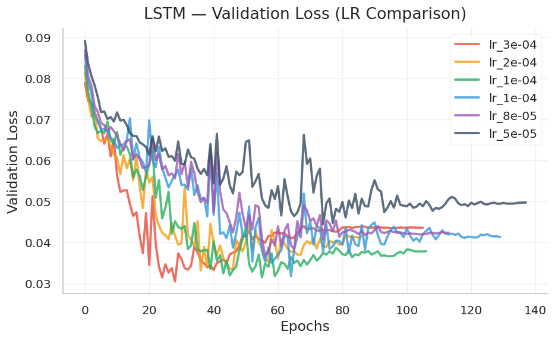

```
Saved plot: /content/drive/MyDrive/Projects/AImSecure/Laboratory2/results/images/task3_plots/lstm_diagnosis.png
```

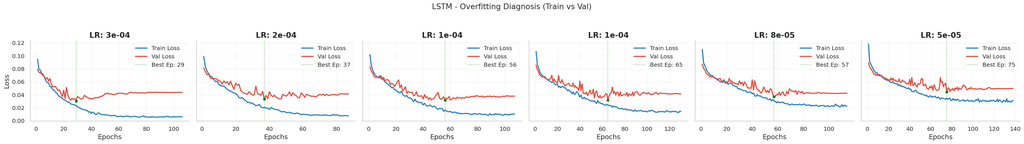

```python
# --- Plot loss curves ---

# Plot comparison
plot_lr_comparison(histories_lstm, "LSTM", save_dir)

#Plot Train vs Validation
plot_train_val_grid(histories_lstm, "LSTM", save_dir)
```

```
Saved plot: /content/drive/MyDrive/Projects/AImSecure/Laboratory2/results/images/task3_plots/lstm_f1_comparison.png
```

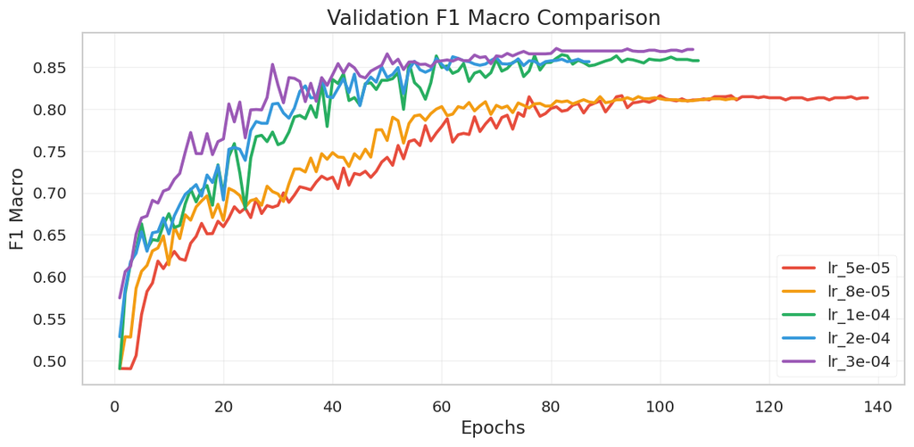

```python
# --- Plot Validation F1 Macro for LSTM ---
plot_training_metrics(histories_lstm, save_dir=save_dir, plot_name="lstm_f1_comparison")
```

```python
# --- Evaluate validation and test sets for ALL learning rates ---

print("\n" + "=" * 80)
print("Evaluation for ALL LSTM RNN learning rates")
print("=" * 80)

for lr in learning_rates_lstm: # Changed 'learning_rates' to 'learning_rates_lstm'
    model = models_lstm[lr]

    print(f"\n{'='*60}")
    print(f"LSTM RNN with lr={lr:.0e}")
    print(f"{'='*60}")

    # Validation evaluation
    y_val_true, y_val_pred = predict_loader(model, val_loader)
    print(f'\nValidation report (LSTM RNN - lr={lr:.0e}):')
    print(classification_report(y_val_true, y_val_pred, digits=4, zero_division=0))

    # Test evaluation
    y_test_true, y_test_pred = predict_loader(model, test_loader)
    print(f'Test report (LSTM RNN - lr={lr:.0e}):')
    print(classification_report(y_test_true, y_test_pred, digits=4, zero_division=0))

# Select the restored model using validation metrics only
best_lstm_lr_value, lstm_selection_table = select_best_rnn_model(
    'Bidirectional LSTM', models_lstm, histories_lstm, val_loader
)
best_lr_lstm = (best_lstm_lr_value, histories_lstm[best_lstm_lr_value])
print(f"\n{'='*60}")
print(
    f"Best Bidirectional LSTM - LR: {best_lr_lstm[0]:.0e} "
    f"(Val Macro F1: {lstm_selection_table.loc[0, 'val_macro_f1']:.4f})"
)
print(f"{'='*60}")
```

```
================================================================================
Evaluation for ALL LSTM RNN learning rates
================================================================================

============================================================
LSTM RNN with lr=5e-05
============================================================

Validation report (LSTM RNN - lr=5e-05):
              precision    recall  f1-score   support

           0     0.5817    0.7295    0.6473       122
           1     0.9894    0.9796    0.9845      3143

    accuracy                         0.9703      3265
   macro avg     0.7855    0.8546    0.8159      3265
weighted avg     0.9742    0.9703    0.9719      3265

Test report (LSTM RNN - lr=5e-05):
              precision    recall  f1-score   support

           0     0.6066    0.6091    0.6078       243
           1     0.9848    0.9847    0.9847      6262

    accuracy                         0.9706      6505
   macro avg     0.7957    0.7969    0.7963      6505
weighted avg     0.9707    0.9706    0.9707      6505


============================================================
LSTM RNN with lr=8e-05
============================================================

Validation report (LSTM RNN - lr=8e-05):
              precision    recall  f1-score   support

           0     0.5687    0.7459    0.6454       122
           1     0.9900    0.9780    0.9840      3143

    accuracy                         0.9694      3265
```

[output cut: 113 more lines]

```

Automatic selection for Bidirectional LSTM
Ranking criterion: validation macro F1, then validation accuracy, then checkpoint validation loss
 learning_rate  val_macro_f1  val_accuracy  checkpoint_val_loss  checkpoint_epoch
       0.00030      0.872171      0.980092             0.043708                81
       0.00015      0.864745      0.977948             0.036980                82
       0.00010      0.863316      0.978867             0.040234               105
       0.00020      0.862313      0.978867             0.040708                62
       0.00005      0.815883      0.970291             0.049484               113
       0.00008      0.814692      0.969372             0.042487                89
Selected Bidirectional LSTM: lr=3e-04, validation macro F1=0.8722, checkpoint epoch=81

============================================================
Best Bidirectional LSTM - LR: 3e-04 (Val Macro F1: 0.8722)
============================================================
```

```
================================================================================
Confusion matrices for ALL LSTM RNN learning rates - VALIDATION
================================================================================

Generating confusion matrix for LSTM RNN with lr=5e-05...
Saved plot: /content/drive/MyDrive/Projects/AImSecure/Laboratory2/results/images/task3_plots/cm_lstm_rnn_(lr=5e_05).png
```

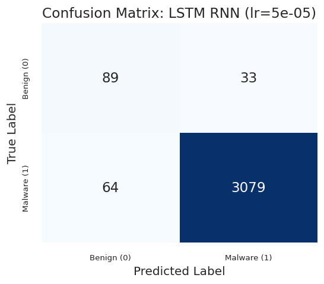

```
Generating confusion matrix for LSTM RNN with lr=8e-05...
Saved plot: /content/drive/MyDrive/Projects/AImSecure/Laboratory2/results/images/task3_plots/cm_lstm_rnn_(lr=8e_05).png
```

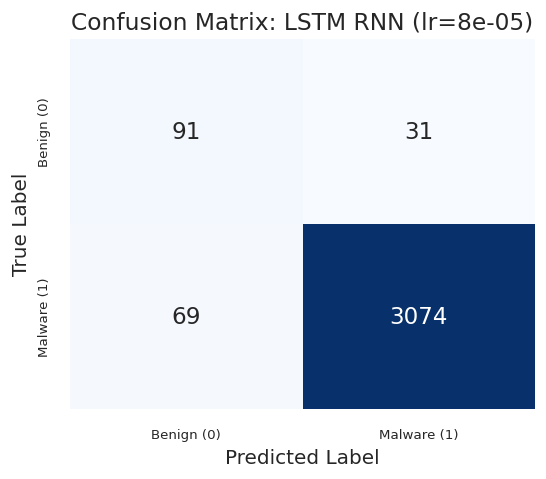

```
Generating confusion matrix for LSTM RNN with lr=1e-04...
Saved plot: /content/drive/MyDrive/Projects/AImSecure/Laboratory2/results/images/task3_plots/cm_lstm_rnn_(lr=1e_04).png
```

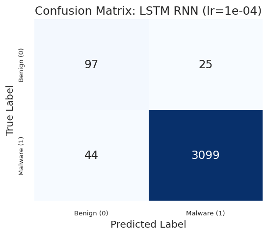

```
Generating confusion matrix for LSTM RNN with lr=1e-04...
Saved plot: /content/drive/MyDrive/Projects/AImSecure/Laboratory2/results/images/task3_plots/cm_lstm_rnn_(lr=1e_04).png
```

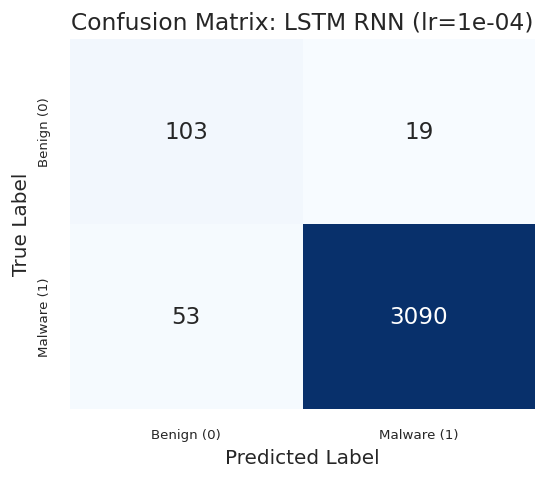

```
Generating confusion matrix for LSTM RNN with lr=2e-04...
Saved plot: /content/drive/MyDrive/Projects/AImSecure/Laboratory2/results/images/task3_plots/cm_lstm_rnn_(lr=2e_04).png
```

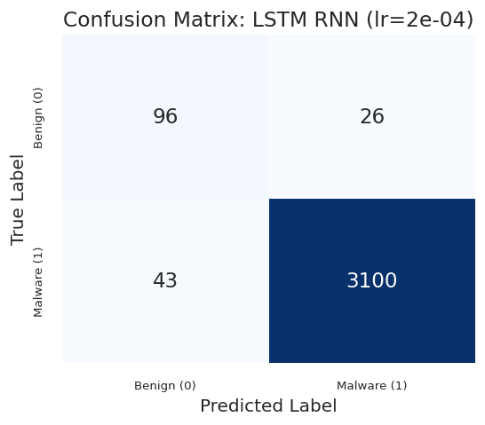

```
Generating confusion matrix for LSTM RNN with lr=3e-04...
Saved plot: /content/drive/MyDrive/Projects/AImSecure/Laboratory2/results/images/task3_plots/cm_lstm_rnn_(lr=3e_04).png
```

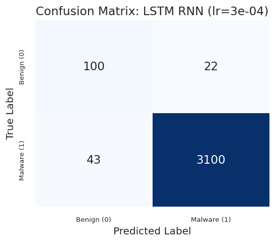

```python
# --- Plot confusion matrices for ALL learning rates - VALIDATION ---

print("\n" + "=" * 80)
print("Confusion matrices for ALL LSTM RNN learning rates - VALIDATION")
print("=" * 80)

for lr in learning_rates_lstm:
    model = models_lstm[lr]
    print(f"\nGenerating confusion matrix for LSTM RNN with lr={lr:.0e}...")

    plot_cm_task3(model=model, loader=val_loader, model_name=f"LSTM RNN (lr={lr:.0e})", save_dir=save_dir)
```

```
================================================================================
Confusion matrices for ALL LSTM RNN learning rates - TEST
================================================================================

Generating confusion matrix for LSTM RNN with lr=5e-05...
Saved plot: /content/drive/MyDrive/Projects/AImSecure/Laboratory2/results/images/task3_plots/cm_lstm_rnn_(lr=5e_05).png
```

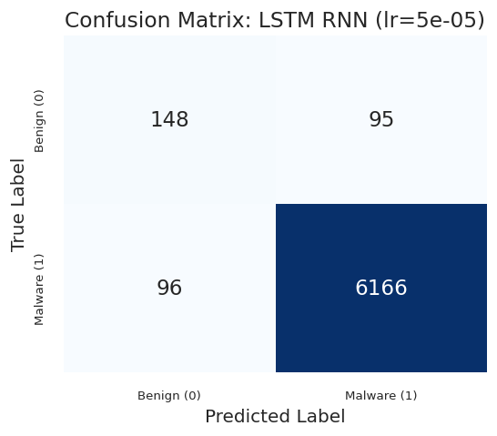

```
Generating confusion matrix for LSTM RNN with lr=8e-05...
Saved plot: /content/drive/MyDrive/Projects/AImSecure/Laboratory2/results/images/task3_plots/cm_lstm_rnn_(lr=8e_05).png
```

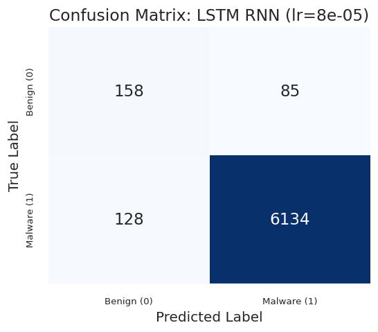

```
Generating confusion matrix for LSTM RNN with lr=1e-04...
Saved plot: /content/drive/MyDrive/Projects/AImSecure/Laboratory2/results/images/task3_plots/cm_lstm_rnn_(lr=1e_04).png
```

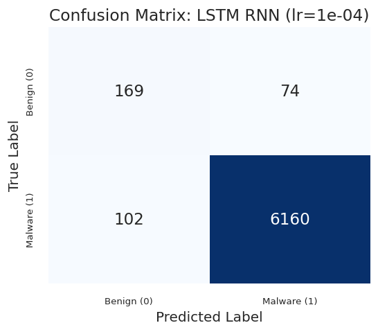

```
Generating confusion matrix for LSTM RNN with lr=1e-04...
Saved plot: /content/drive/MyDrive/Projects/AImSecure/Laboratory2/results/images/task3_plots/cm_lstm_rnn_(lr=1e_04).png
```

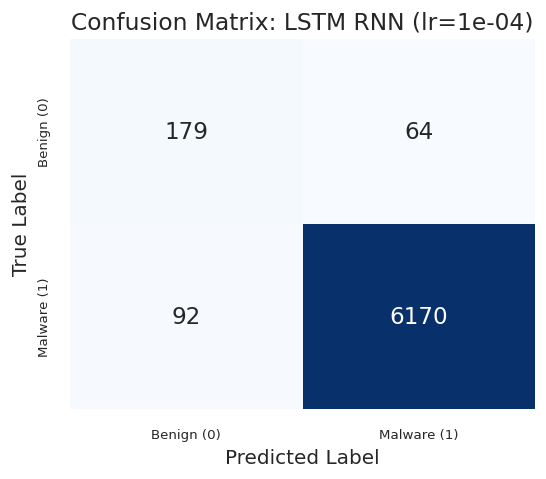

```
Generating confusion matrix for LSTM RNN with lr=2e-04...
Saved plot: /content/drive/MyDrive/Projects/AImSecure/Laboratory2/results/images/task3_plots/cm_lstm_rnn_(lr=2e_04).png
```

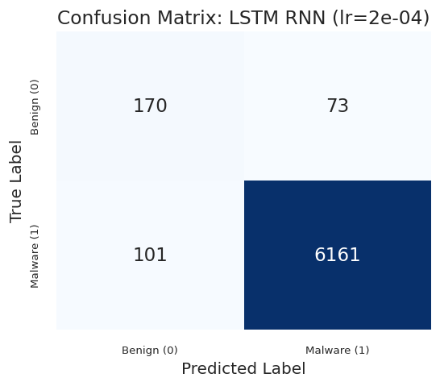

```
Generating confusion matrix for LSTM RNN with lr=3e-04...
Saved plot: /content/drive/MyDrive/Projects/AImSecure/Laboratory2/results/images/task3_plots/cm_lstm_rnn_(lr=3e_04).png
```

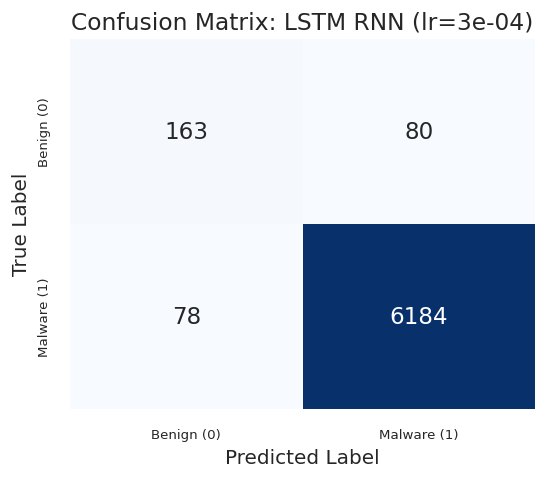

```python
# --- Plot confusion matrices for ALL learning rates - TEST ---

print("\n" + "=" * 80)
print("Confusion matrices for ALL LSTM RNN learning rates - TEST")
print("=" * 80)

for lr in learning_rates_lstm:
    model = models_lstm[lr]
    print(f"\nGenerating confusion matrix for LSTM RNN with lr={lr:.0e}...")

    plot_cm_task3(model=model, loader=test_loader, model_name=f"LSTM RNN (lr={lr:.0e})", save_dir=save_dir)
```

#### Q: Is the RNN training as stable as the FFNN's one?

No. RNN training is less stable than FFNN training. The FFNN validation-loss curves are comparatively smoother, while the recurrent models show more oscillations and stronger sensitivity to the learning rate.

This happens because recurrent models backpropagate through time, producing a deeper computational graph whose effective depth depends on the sequence length. This increases the risk of vanishing or unstable gradients, especially for vanilla RNNs.

Among the recurrent architectures, the bidirectional LSTM is the most stable and effective in our experiments. With the common selection protocol based on validation macro F1, it selects `lr=3e-4` and reaches validation macro F1 `0.8722`, higher than the selected Simple RNN (`0.8601`) and Bi-RNN (`0.8222`). Its checkpoint validation loss is also the lowest among the selected recurrent models (`0.0437`). The gating mechanism of the LSTM helps regulate what information is kept or forgotten, making optimization more reliable than in vanilla recurrent variants.

#### Q: How does your model's performance compare to the simple frequency baseline?

The frequency baseline remains very competitive in accuracy, reaching `96.97%` on the test set, but its macro F1 is `0.7223` and its benign recall is only `0.3457`. This means that it is excellent at recognizing malware (`0.9939` recall), but it misclassifies many benign samples as malware.

The recurrent models improve the balance between the two classes. The selected Simple RNN reaches test accuracy `97.48%`, macro F1 `0.8247`, and benign recall `0.6626`, already improving strongly over the frequency baseline in macro F1. The selected Bi-RNN reaches test macro F1 `0.8020`, accuracy `96.91%`, and benign recall `0.6749`.

The selected bidirectional LSTM is the strongest recurrent model in this run. With `lr=3e-4`, it reaches test accuracy `97.57%`, macro F1 `0.8305`, and benign recall `0.6708`. It therefore beats the frequency baseline both in macro F1 and in accuracy, while providing a much better balance between benign and malware recognition. Overall, the recurrent results show that temporal order contains discriminative information that the frequency baseline cannot capture.

```python
# =============================================================================
# FINAL SUMMARY
# =============================================================================

# Helper function to extract macro avg from the best model
def get_macro_avg_stats(model, loader):
    # Predict using your existing helper function
    y_true, y_pred = predict_loader(model, loader)
    # Get report as a DICTIONARY, not a string
    report_dict = classification_report(y_true, y_pred, output_dict=True, zero_division=0)
    return report_dict['macro avg']

# --- 1. Prepare Stats for Simple RNN ---
# Retrieve the actual model object using the best LR key
best_model_simple_obj = models_simple[best_lr_simple[0]]
macro_simple = get_macro_avg_stats(best_model_simple_obj, val_loader)

# --- 2. Prepare Stats for Bi-RNN ---
best_model_bi_obj = models_bi[best_lr_bi[0]]
macro_bi = get_macro_avg_stats(best_model_bi_obj, val_loader)

# --- 3. Prepare Stats for LSTM ---
best_model_lstm_obj = models_lstm[best_lr_lstm[0]]
macro_lstm = get_macro_avg_stats(best_model_lstm_obj, val_loader)

# --- PRINTING THE REPORT ---

print("\n" + "=" * 90)
print("TASK 3 SUMMARY: Models selected by validation macro F1")
print("=" * 90)
# Header for the manual table we are creating
print(f"{'Model':<20} | {'Best LR':<10} | {'Ckpt Loss':<10} | {'Macro P':<8} {'Macro R':<8} {'Macro F1':<8} | {'Time':<10}")
print("-" * 90)

# 1. Simple RNN
t_simple = time.strftime('%H:%M:%S', time.gmtime(elapsed_simple[best_lr_simple[0]]))
print(f"{'Simple RNN':<20} | {best_lr_simple[0]:.0e}      | {best_lr_simple[1]['best_val_loss_at_checkpoint']:.4f}     | "
      f"{macro_simple['precision']:.4f}   {macro_simple['recall']:.4f}   {macro_simple['f1-score']:.4f}   | {t_simple}")

# 2. Bi-RNN
t_bi = time.strftime('%H:%M:%S', time.gmtime(elapsed_bi[best_lr_bi[0]]))
print(f"{'Bidirectional RNN':<20} | {best_lr_bi[0]:.0e}      | {best_lr_bi[1]['best_val_loss_at_checkpoint']:.4f}     | "
      f"{macro_bi['precision']:.4f}   {macro_bi['recall']:.4f}   {macro_bi['f1-score']:.4f}   | {t_bi}")

# 3. LSTM
t_lstm = time.strftime('%H:%M:%S', time.gmtime(elapsed_lstm[best_lr_lstm[0]]))
print(f"{'Bi-LSTM':<20} | {best_lr_lstm[0]:.0e}      | {best_lr_lstm[1]['best_val_loss_at_checkpoint']:.4f}     | "
      f"{macro_lstm['precision']:.4f}   {macro_lstm['recall']:.4f}   {macro_lstm['f1-score']:.4f}   | {t_lstm}")
```

```
==========================================================================================
TASK 3 SUMMARY: Models selected by validation macro F1
==========================================================================================
Model                | Best LR    | Ckpt Loss  | Macro P  Macro R  Macro F1 | Time
------------------------------------------------------------------------------------------
Simple RNN           | 2e-04      | 0.0567     | 0.8533   0.8672   0.8601   | 00:05:19
Bidirectional RNN    | 1e-04      | 0.0498     | 0.7882   0.8667   0.8222   | 00:08:09
Bi-LSTM              | 3e-04      | 0.0437     | 0.8461   0.9030   0.8722   | 00:08:05
```

## Task 4 - Graph Neural Network (GNN)

In this task we model API-call sequences as graphs and train GNN architectures (GCN, GraphSAGE, GAT) to classify samples. We reuse the lab preprocessing and reporting utilities for consistency.

```python
# Create directory for plots
save_dir = results_path + 'images/' + 'task4_plots/'
os.makedirs(save_dir, exist_ok=True)
```

### Modeling API Sequences as Graphs

```python
df_train
```

|  | api_call_sequence | is_malware | seq_length | seq_fixed | seq_sequential_ids |
| --- | --- | --- | --- | --- | --- |
| 0 | [LdrGetDllHandle, LdrGetProcedureAddress, LdrL... | 1 | 73 | [LdrGetDllHandle, LdrGetProcedureAddress, LdrL... | [117, 118, 119, 118, 117, 118, 86, 123, 201, 2... |
| 1 | [NtAllocateVirtualMemory, LdrLoadDll, LdrGetPr... | 1 | 88 | [NtAllocateVirtualMemory, LdrLoadDll, LdrGetPr... | [133, 119, 118, 82, 80, 137, 82, 152, 153, 163... |
| 2 | [FindResourceExW, LoadResource, FindResourceEx... | 1 | 79 | [FindResourceExW, LoadResource, FindResourceEx... | [46, 121, 46, 121, 46, 121, 46, 121, 46, 121, ... |
| 3 | [FindResourceExW, LoadResource, FindResourceEx... | 1 | 71 | [FindResourceExW, LoadResource, FindResourceEx... | [46, 121, 46, 121, 46, 121, 46, 121, 46, 121, ... |
| 4 | [LdrGetProcedureAddress, SetErrorMode, LdrLoad... | 1 | 63 | [LdrGetProcedureAddress, SetErrorMode, LdrLoad... | [118, 219, 119, 219, 81, 46, 121, 46, 121, 46,... |
| ... | ... | ... | ... | ... | ... |
| 16320 | [LdrGetProcedureAddress, LdrLoadDll, LdrGetPro... | 1 | 64 | [LdrGetProcedureAddress, LdrLoadDll, LdrGetPro... | [118, 119, 118, 119, 118, 119, 118, 119, 118, ... |
| 16321 | [NtClose, LdrGetProcedureAddress, CryptCreateH... | 1 | 78 | [NtClose, LdrGetProcedureAddress, CryptCreateH... | [134, 118, 24, 118, 30, 118, 135, 66, 221, 166... |
| 16322 | [LdrGetProcedureAddress, LdrGetDllHandle, LdrG... | 1 | 84 | [LdrGetProcedureAddress, LdrGetDllHandle, LdrG... | [118, 117, 118, 81, 216, 119, 118, 46, 121, 46... |
| 16323 | [LdrGetProcedureAddress, LdrGetDllHandle, LdrG... | 1 | 62 | [LdrGetProcedureAddress, LdrGetDllHandle, LdrG... | [118, 117, 118, 117, 118, 117, 118, 117, 118, ... |
| 16324 | [SetFilePointer, NtReadFile, SetFilePointer, N... | 1 | 77 | [SetFilePointer, NtReadFile, SetFilePointer, N... | [221, 166, 221, 166, 221, 45, 121, 133, 146, 1... |

16325 rows × 5 columns

```python
df_train_split, df_val = train_test_split(
    df_train,
    test_size=0.2,
    random_state=42,
    stratify=df_train['is_malware'],  # Preserve class balance
    shuffle=True
)
```

```python
# Use original api_call_sequence (not truncated seq_sequential_ids)
# GNNs can handle variable-length graphs, so we use full sequences
X_train_split = df_train_split['api_call_sequence'].values
y_train_split = df_train_split['is_malware'].values

X_val = df_val['api_call_sequence'].values
y_val = df_val['is_malware'].values

X_test = df_test['api_call_sequence'].values
y_test = df_test['is_malware'].values

print(f"Train length: {len(X_train_split)}")
print(f"Val length: {len(X_val)}")
print(f"Test length: {len(X_test)}")
```

```
Train length: 13060
Val length: 3265
Test length: 6505
```

```python
# --- Graph Construction ---

def create_graph_from_sequence(sequence, api_to_id, label, window_size=1):
    """
    Create a sparse graph containing ONLY the nodes present in the sequence.
    Accepts API name strings and converts them to integer IDs using api_to_id mapping.
    Unknown APIs are mapped to UNK_IDX (index 1).
    """
    UNK_IDX = 1  # Same as defined in Task 3

    # 1. Convert API names to integer IDs (handle unknown APIs with UNK_IDX)
    sequence_ids = [api_to_id.get(api, UNK_IDX) for api in sequence]

    # 2. Identify unique node IDs present in this sequence
    # IMPORTANT: Filter out padding (0) before creating node set
    unique_api_ids = sorted(list(set([api_id for api_id in sequence_ids if api_id != 0])))
    num_nodes = len(unique_api_ids)

    # 3. Create a mapping from Global API ID -> Local Graph Node Index
    global_to_local = {global_id: local_id for local_id, global_id in enumerate(unique_api_ids)}

    # 4. Create Node Features (The Global IDs to be fed into the Embedding Layer)
    x = torch.tensor(unique_api_ids, dtype=torch.long).unsqueeze(1)

    # 5. Create Edges (Transition Graph)
    src_list = []
    dst_list = []

    # Sliding window to find transitions
    for i in range(len(sequence_ids) - window_size):
        global_src = sequence_ids[i]
        global_dst = sequence_ids[i + window_size]

        # Skip padding (0) if present
        if global_src == 0 or global_dst == 0:
            continue

        # Map to local indices
        src_list.append(global_to_local[global_src])
        dst_list.append(global_to_local[global_dst])

    edge_index = torch.tensor([src_list, dst_list], dtype=torch.long)

    data = Data(
        x=x,
        edge_index=edge_index,
        y=torch.tensor([label], dtype=torch.float32),
        num_nodes=num_nodes
    )

    return data

def create_graphs_from_sequences(sequences, api_to_id, labels, window_size=1):
    graph_data_list = []
    for sequence, label in zip(sequences, labels):
        # Ensure sequence is a list (handles numpy arrays)
        seq_list = sequence if isinstance(sequence, list) else list(sequence)
        data = create_graph_from_sequence(seq_list, api_to_id, label, window_size)
        graph_data_list.append(data)

    # Sanity check for each graph
    if data.edge_index.numel() > 0 and data.edge_index.max().item() >= data.num_nodes:
        print(f"Warning: Graph {idx} has invalid edge index!")

    return graph_data_list

# --- Execute Creation ---
print("Creating sparse graphs...")
train_graphs = create_graphs_from_sequences(X_train_split, api_to_id, y_train_split)
val_graphs = create_graphs_from_sequences(X_val, api_to_id, y_val)
test_graphs = create_graphs_from_sequences(X_test, api_to_id, y_test)

print(f"Training graphs: {len(train_graphs)}")
print(f"First graph nodes: {train_graphs[0].num_nodes} (Subset of total vocab)")
print(f"First graph edges: {train_graphs[0].num_edges}")
```

```
Creating sparse graphs...
Training graphs: 13060
First graph nodes: 21 (Subset of total vocab)
First graph edges: 80
```

```
Plotting example graphs...

Training set example:
```

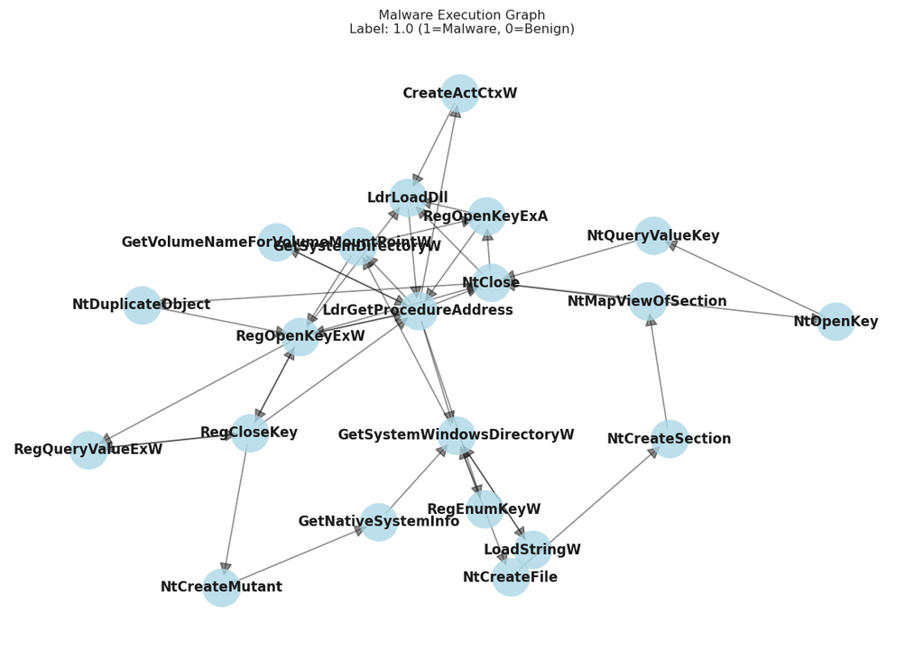

```
Validation set example:
```

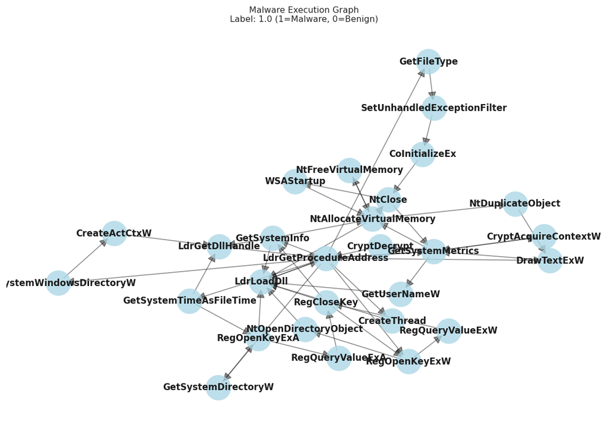

```
Test set example:
```

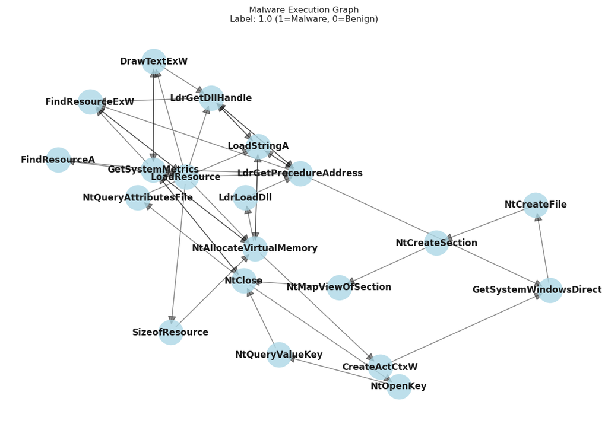

```python
import networkx as nx
import matplotlib.pyplot as plt
from torch_geometric.utils import to_networkx

def visualize_graph(data, id_to_api_mapping=None):
    # Convert PyG data to NetworkX
    G = to_networkx(data, to_undirected=False) # Keep it directed to see flow

    plt.figure(figsize=(12, 8))

    # Layout (Spring layout tends to show clusters and loops well)
    pos = nx.spring_layout(G, seed=42)

    # Draw nodes
    nx.draw_networkx_nodes(G, pos, node_size=800, node_color='lightblue', alpha=0.8)

    # Draw edges (with arrows)
    nx.draw_networkx_edges(G, pos, width=1.0, alpha=0.5, arrowstyle='-|>', arrowsize=20)

    # Labels: If you have the mapping, show API names. Otherwise show IDs.
    if id_to_api_mapping:
        # Get the Global API ID from data.x for each local node index
        labels = {i: id_to_api_mapping.get(data.x[i].item(), str(i)) for i in range(data.num_nodes)}
        nx.draw_networkx_labels(G, pos, labels, font_size=10, font_weight="bold")
    else:
        nx.draw_networkx_labels(G, pos)

    plt.title(f"Malware Execution Graph\nLabel: {data.y.item()} (1=Malware, 0=Benign)")
    plt.axis('off')
    plt.show()

# --- RUN THE CHECK ---
# Plot example graphs from each dataset
print("Plotting example graphs...\n")
print("Training set example:")
visualize_graph(train_graphs[0], id_to_api)

print("\nValidation set example:")
visualize_graph(val_graphs[0], id_to_api)

print("\nTest set example:")
visualize_graph(test_graphs[0], id_to_api)
```

```python
data = train_graphs[0]

print(f"1. Node Features Shape: {data.x.shape}")
print(f"   → {data.num_nodes} unique APIs in this sequence")

print(f"\n2. Edge Index Shape: {data.edge_index.shape}")
print(f"   → {data.num_edges} transitions (edges) in the sequence")

print(f"\n3. Max Node Index: {data.edge_index.max().item()}")
print(f"   → Valid range: [0, {data.num_nodes - 1}]")
if data.edge_index.numel() > 0:
    is_valid = data.edge_index.max().item() < data.num_nodes
    print(f"   → {'✓ VALID' if is_valid else '✗ INVALID - edges point to non-existent nodes'}")
else:
    print(f"   → No edges in this graph")

print(f"\n4. Label Shape: {data.y.shape}")
print(f"   → Label value: {data.y.item()} ({'Malware' if data.y.item() == 1 else 'Benign'})")

print(f"\n5. Summary:")
print(f"   → Graph has {data.num_nodes} nodes and {data.num_edges} edges")
print(f"   → Sparsity: {(data.num_edges / (data.num_nodes * (data.num_nodes - 1))) * 100:.2f}% (if fully connected)")
```

```
1. Node Features Shape: torch.Size([21, 1])
   → 21 unique APIs in this sequence

2. Edge Index Shape: torch.Size([2, 80])
   → 80 transitions (edges) in the sequence

3. Max Node Index: 20
   → Valid range: [0, 20]
   → ✓ VALID

4. Label Shape: torch.Size([1])
   → Label value: 1.0 (Malware)

5. Summary:
   → Graph has 21 nodes and 80 edges
   → Sparsity: 19.05% (if fully connected)
```

```python
# Get the raw sequence and the graph
raw_seq_ids = X_train_split[0] # The list of IDs: [117, 118, 119...]
graph = train_graphs[0]

# Check 1: Unique counts
unique_apis_raw = len(set(raw_seq_ids))
# Padding (0) is usually removed in your graph logic, so:
if 0 in raw_seq_ids: unique_apis_raw -= 1

print(f"Unique APIs in raw sequence: {unique_apis_raw}")
print(f"Nodes in Graph:              {graph.num_nodes}")
# THESE SHOULD MATCH EXACTLY.

# Check 2: Transitions vs Edges
# Raw edges = length of sequence - 1 (minus padding transitions)
# Note: Your graph combines duplicate edges.
# If raw sequence is A->B->A->B, graph has edges (A,B) and (B,A).
# This check is qualitative: Does graph.num_edges roughly track with sequence complexity?
print(f"Raw sequence length: {len([x for x in raw_seq_ids if x != 0])}")
print(f"Graph edges:         {graph.num_edges}")
```

```
Unique APIs in raw sequence: 21
Nodes in Graph:              21
Raw sequence length: 81
Graph edges:         80
```

#### Q: Do you still have to pad your data? If yes, how?

No. The graph-based representation eliminates the need for padding. Each API sequence is converted into its own graph, where nodes correspond to the unique API calls appearing in the sequence and edges represent transitions between consecutive calls.

Longer sequences simply create more transitions and possibly more nodes. Shorter sequences create smaller graphs. PyTorch Geometric can batch these variable-sized graphs by merging them into a larger disconnected graph and using a `batch` vector to keep track of graph membership.

As a result, no dummy padding nodes or padding edges are required. The model works directly on the sparse graph structure of each execution trace.

#### Q: Do you have to truncate the testing sequences? Justify your answer.

No. GNNs do not require test-time truncation because there is no fixed-size input vector that would overflow when a sequence is longer than expected. A longer sequence simply generates additional edges, and possibly additional nodes, in its graph representation.

Truncating a test sequence would remove transitions from the graph and would therefore discard part of the behavioral structure we are trying to model. Since the GNN can process variable-sized graphs through PyTorch Geometric batching and graph-level pooling, keeping the full test sequence is the correct choice.

#### Q: What is the advantage of modeling your problem with a GNN compared to an RNN? What do you lose?

The advantage of a GNN is that it models the API trace as a transition structure rather than only as a left-to-right chain. If an API call repeatedly transitions to several other calls, or if a small cycle appears multiple times, the GNN can aggregate information from those local neighborhoods and learn structural motifs that may be discriminative for malware detection.

This representation also handles variable-length sequences naturally: graphs can have different numbers of nodes and edges, and batching does not require padding or truncation. Message passing can summarize repeated transition patterns and relationships between API calls in a way that is different from the hidden-state memory of an RNN.

What we lose is strict chronological information. After converting the sequence into a graph and applying graph-level pooling, the model knows that certain API calls are connected, but it does not know exactly whether a transition happened early or late in the trace. RNNs preserve this temporal evolution explicitly through their hidden states, while GNNs emphasize transition structure.

### GNN Training and Helper Functions

We need new training and prediction functions, as the `PyGDataLoader` returns batches differently from the standard `DataLoader`.

```python
# Create DataLoader for batching
train_loader = PyGDataLoader(train_graphs, batch_size=32, shuffle=True)
val_loader = PyGDataLoader(val_graphs, batch_size=32, shuffle=False)
test_loader = PyGDataLoader(test_graphs, batch_size=32, shuffle=False)

print(f"Train loader: {len(train_loader)}, Validation loader: {len(val_loader)}, Test loader: {len(test_loader)}")
```

```
Train loader: 409, Validation loader: 103, Test loader: 204
```

```python
# ============================================================================
# GNN TRAINING FUNCTION (with Macro F1 tracking)
# ============================================================================

def train_gnn_common(model, train_loader, val_loader, optimizer, criterion, epochs=50, min_delta=0.00001, patience=20):
    """
    Train a GNN model with early stopping and track macro F1 score.
    """
    device = next(model.parameters()).device

    best_val = math.inf
    best_state = None
    trigger = 0
    history = {'train_loss': [], 'val_loss': [], 'val_f1_macro': []}
    start_time = time.time()

    for epoch in range(1, epochs + 1):
        model.train()
        train_losses = []
        for data in train_loader:
            data = data.to(device)
            optimizer.zero_grad()
            outputs = model(data)
            loss = criterion(outputs, data.y.unsqueeze(1).float())
            loss.backward()
            optimizer.step()
            train_losses.append(loss.item())
        train_loss = float(np.mean(train_losses)) if train_losses else 0.0

        # Validation
        model.eval()
        val_losses = []
        all_preds = []
        all_targets = []
        with torch.no_grad():
            for data in val_loader:
                data = data.to(device)
                outputs = model(data)
                loss = criterion(outputs, data.y.unsqueeze(1).float())
                val_losses.append(loss.item())

                # Collect predictions for F1 score
                # FIX: use view(-1) instead of squeeze() to handle single-element batches
                probs = torch.sigmoid(outputs).view(-1)
                preds = (probs > 0.5).long()

                # FIX: convert to list properly to handle both single and multi-element tensors
                all_preds.extend(preds.cpu().tolist())
                all_targets.extend(data.y.cpu().tolist())

        val_loss = float(np.mean(val_losses)) if val_losses else 0.0
        val_f1_macro = f1_score(all_targets, all_preds, average='macro', zero_division=0)

        history['train_loss'].append(train_loss)
        history['val_loss'].append(val_loss)
        history['val_f1_macro'].append(val_f1_macro)

        if (epoch % 10 == 0) or (epoch == 1) or (epoch == epochs):
            print(f'Epoch {epoch}/{epochs} - Train Loss: {train_loss:.4f} - Val Loss: {val_loss:.4f} - Val F1: {val_f1_macro:.4f}')

        # Early stopping logic
        if val_loss < best_val - min_delta:
            best_val = val_loss
            best_state = {k: v.cpu().clone() for k, v in model.state_dict().items()}
            trigger = 0
        else:
            trigger += 1
            if trigger >= patience:
                print(f'Early stopping at epoch {epoch} (best val loss {best_val:.6f})')
                break

    elapsed = time.time() - start_time

    if best_state is not None:
        model.load_state_dict(best_state)
        model.to(device)

    return model, history, elapsed
```

```python
# --- GNN Prediction Helper ---

def predict_loader_gnn(model, loader, threshold=0.5):
    model.eval()

    # Detect device from model parameters
    device = next(model.parameters()).device

    ys_true = []
    ys_pred = []
    with torch.no_grad():
        for data in loader:
            # Move batch to device
            data = data.to(device)

            out = model(data)
            probs = torch.sigmoid(out).cpu().numpy().ravel()
            preds = (probs >= threshold).astype(int)

            # Get true labels from the DataBatch object
            ys_true.extend(data.y.cpu().numpy().ravel().astype(int).tolist())
            ys_pred.extend(preds.tolist())

    return np.array(ys_true, dtype=int), np.array(ys_pred, dtype=int)
```

```python
def plot_cm_task4(model, loader, model_name, save_dir=None):
    """
    Specific for GNNs. Uses your existing 'predict_loader_gnn' logic.
    """
    # Use the GNN specific helper
    y_true, y_pred = predict_loader_gnn(model, loader)

    # Plot
    _internal_plot_cm(y_true, y_pred, model_name, save_dir)
```

### GNN Variations

Now we define and train the three GNN architectures as requested by the lab PDF. We will use the same hyperparameters (`vocab_size`, `embed_dim`, `hidden_dim`) for a fair comparison. We also re-use the `pos_weight` from Task 3 to handle the imbalanced dataset.

```python
# Hyperparameters for all GNNs
VOCAB_SIZE_GNN = len(api_to_id)
EMBED_DIM_GNN = 32
HIDDEN_DIM_GNN = 64
OUTPUT_DIM_GNN = 1
EPOCHS_GNN = 100
PATIENCE_GNN = 15
MIN_DELTA_GNN = 0.0001
LR_GNN = 5e-4 # Learning rate

# Re-compute pos_weight for the GNN training subset
pos_weight_gnn = compute_pos_weight(y_train_split).to(device)

criterion_gnn = nn.BCEWithLogitsLoss(pos_weight=pos_weight_gnn)


def select_best_gnn_model(architecture_name, models, histories, elapsed_times, val_loader):
    """
    Select the best Task 4 model automatically.

    Primary criterion: validation macro F1 evaluated on the restored model.
    Tie-breakers: validation accuracy of the restored model, then minimum validation loss.
    This avoids manually hardcoding the selected learning rate.
    """
    selection_rows = []

    for lr_label, model in models.items():
        history = histories[lr_label]
        y_val_true, y_val_pred = predict_loader_gnn(model, val_loader)

        last_history_val_f1 = history['val_f1_macro'][-1] if history.get('val_f1_macro') else float('-inf')
        val_accuracy = accuracy_score(y_val_true, y_val_pred)
        eval_val_f1 = f1_score(y_val_true, y_val_pred, average='macro', zero_division=0)
        min_val_loss = min(history['val_loss']) if history.get('val_loss') else float('inf')

        selection_rows.append({
            'lr_label': lr_label,
            'last_history_val_f1_macro': last_history_val_f1,
            'val_accuracy': val_accuracy,
            'eval_val_f1_macro': eval_val_f1,
            'min_val_loss': min_val_loss,
            'elapsed_s': elapsed_times[lr_label],
        })

    selection_table = pd.DataFrame(selection_rows).sort_values(
        by=['eval_val_f1_macro', 'val_accuracy', 'min_val_loss'],
        ascending=[False, False, True]
    ).reset_index(drop=True)

    best_lr = selection_table.loc[0, 'lr_label']
    best_model = models[best_lr]
    best_history = histories[best_lr]
    best_elapsed = elapsed_times[best_lr]

    print(f"Automatic selection for {architecture_name}")
    print("Ranking criterion: restored-model validation macro F1, then validation accuracy, then minimum validation loss")
    print(selection_table.to_string(index=False))
    print(f"\nSelected best {architecture_name} model: {best_lr}")
    print(f"Restored-model Val F1 Macro: {selection_table.loc[0, 'eval_val_f1_macro']:.4f}")
    print(f"Validation Accuracy: {selection_table.loc[0, 'val_accuracy']:.4f}")

    return best_lr, best_model, best_history, best_elapsed, selection_table


print(f"GNN Vocab Size: {VOCAB_SIZE_GNN}")
print(f"GNN Positive Weight: {pos_weight_gnn.item():.4f}") # Use .item() for scalar tensor print
```

```
Negatives: 489, Positives: 12571
pos_weight (applied to y=1 samples): 0.2000
GNN Vocab Size: 260
GNN Positive Weight: 0.2000
```

#### 1. Simple GCN

This model uses Graph Convolutional Networks (GCN).

```python
# --- 1. GCN Model Definition ---

class GCNmodel(torch.nn.Module):
    def __init__(self, vocab_size, embed_dim, hidden_dim, output_dim):
        super(GCNmodel, self).__init__()

        # Embedding: Maps Global API IDs -> Dense Vector
        self.embedding = nn.Embedding(vocab_size, embed_dim, padding_idx=0)

        # GCN Layers
        self.conv1 = GCNConv(embed_dim, hidden_dim)
        self.conv2 = GCNConv(hidden_dim, hidden_dim)
        self.conv3 = GCNConv(hidden_dim, hidden_dim)

        # Pooling
        self.pool = global_mean_pool

        # Classifier
        self.classifier = nn.Sequential(
            nn.Linear(hidden_dim, hidden_dim),
            nn.ReLU(),
            nn.Dropout(0.5),
            nn.Linear(hidden_dim, output_dim)
        )

    def forward(self, data):
        x, edge_index, batch = data.x, data.edge_index, data.batch

        # x comes in as [num_nodes_in_batch, 1]
        x = x.squeeze(1) # [num_nodes_in_batch]

        # 1. Embedding
        x = self.embedding(x) # [num_nodes, embed_dim]

        # 2. GCN
        x = self.conv1(x, edge_index)
        x = F.relu(x)
        x = F.dropout(x, p=0.2, training=self.training)

        x = self.conv2(x, edge_index)
        x = F.relu(x)
        x = F.dropout(x, p=0.2, training=self.training)

        x = self.conv3(x, edge_index)
        x = F.relu(x)
        x = F.dropout(x, p=0.2, training=self.training)

        # 3. Global Pooling
        # Averages node vectors belonging to the same graph
        x = self.pool(x, batch)

        # 4. Classification
        out = self.classifier(x)
        return out
```

```python
# ============================================================================
# GCN: Training with Multiple Learning Rates
# ============================================================================

gcn_learning_rates = [1e-4, 5e-4, 1e-3]
gcn_lr_labels = ['LR=1e-4', 'LR=5e-4', 'LR=1e-3']

# Storage for results
gcn_histories = {}
gcn_models = {}
gcn_elapsed_times = {}

for lr, lr_label in zip(gcn_learning_rates, gcn_lr_labels):
    print(f"\n{'='*60}")
    print(f"Training GCN with {lr_label}")
    print('='*60)

    # Set seed for reproducibility
    torch.manual_seed(42)
    np.random.seed(42)

    # Create model
    model_gcn_temp = GCNmodel(
        vocab_size=VOCAB_SIZE_GNN,
        embed_dim=EMBED_DIM_GNN,
        hidden_dim=HIDDEN_DIM_GNN,
        output_dim=OUTPUT_DIM_GNN
    ).to(device)

    optimizer_temp = optim.AdamW(model_gcn_temp.parameters(), lr=lr)

    model_gcn_temp, history_temp, elapsed_temp = train_gnn_common(
        model_gcn_temp,
        train_loader,
        val_loader,
        optimizer_temp,
        criterion_gnn,
        epochs=EPOCHS_GNN,
        min_delta=MIN_DELTA_GNN,
        patience=PATIENCE_GNN
    )

    gcn_models[lr_label] = model_gcn_temp
    gcn_histories[lr_label] = history_temp
    gcn_elapsed_times[lr_label] = elapsed_temp

    elapsed_str = time.strftime('%H:%M:%S', time.gmtime(elapsed_temp))
    print(f'\n{lr_label} - Training time: {elapsed_str}')
```

```
============================================================
Training GCN with LR=1e-4
============================================================

LR=1e-4 - Training time: 00:05:38

============================================================
Training GCN with LR=5e-4
============================================================
Early stopping at epoch 49 (best val loss 0.044381)

LR=5e-4 - Training time: 00:02:45

============================================================
Training GCN with LR=1e-3
============================================================
Early stopping at epoch 43 (best val loss 0.047833)

LR=1e-3 - Training time: 00:02:26
```

```
Saved plot: /content/drive/MyDrive/Projects/AImSecure/Laboratory2/results/images/task4_plots/task4_gcn_loss_curves_LR1e-4.png
```

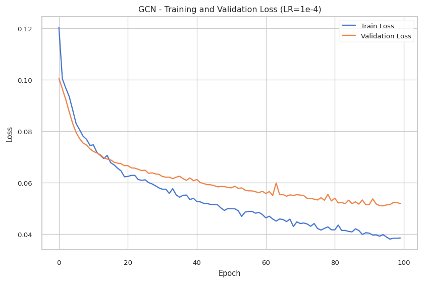

```
Saved plot: /content/drive/MyDrive/Projects/AImSecure/Laboratory2/results/images/task4_plots/task4_gcn_loss_curves_LR5e-4.png
```

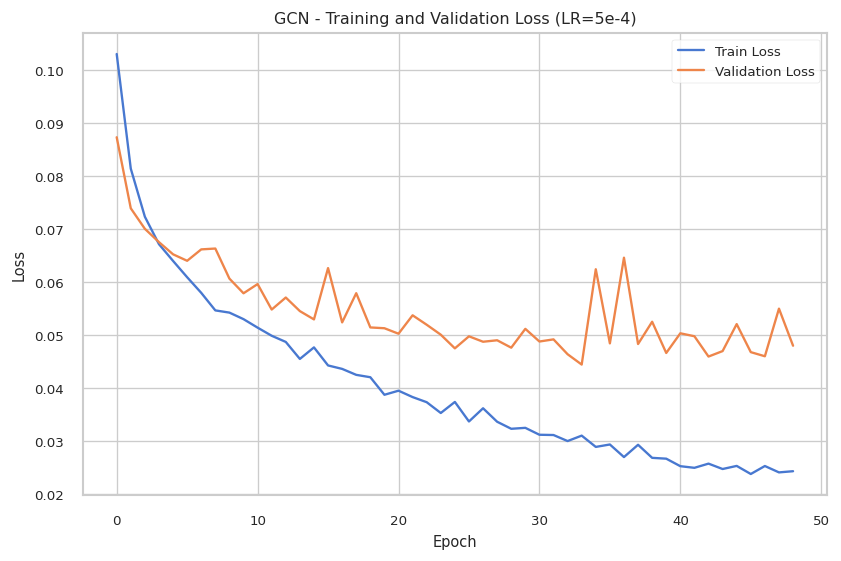

```
Saved plot: /content/drive/MyDrive/Projects/AImSecure/Laboratory2/results/images/task4_plots/task4_gcn_loss_curves_LR1e-3.png
```

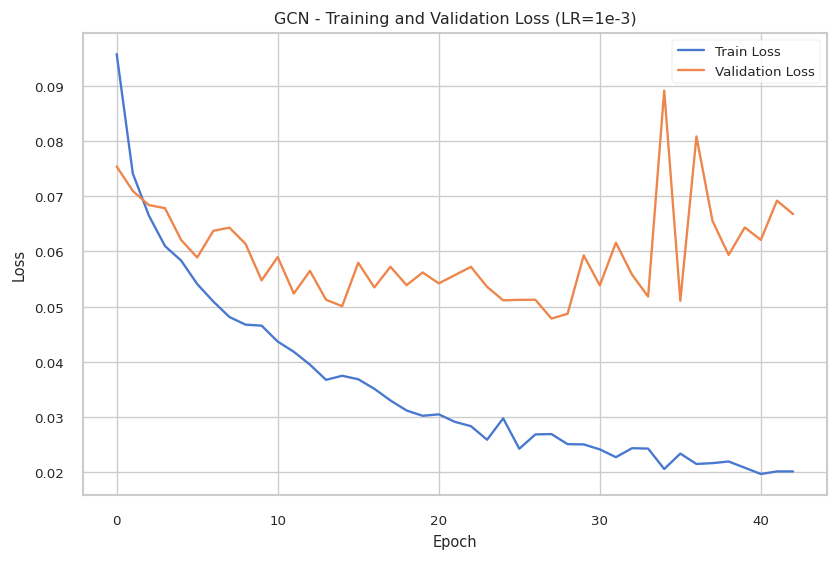

```python
# ============================================================================
# Plot Training/Validation Loss per OGNI learning rate (GCN)
# ============================================================================

for lr_label, history in gcn_histories.items():
    plt.figure(figsize=(8, 5))
    plt.plot(history['train_loss'], label='Train Loss')
    plt.plot(history['val_loss'], label='Validation Loss')
    plt.title(f'GCN - Training and Validation Loss ({lr_label})')
    plt.xlabel('Epoch')
    plt.ylabel('Loss')
    plt.legend()
    plt.grid(True)

    # Nome file unico per ogni lr
    save_plot(plt.gcf(), f'task4_gcn_loss_curves_{lr_label.replace("=", "")}', save_dir)
    plt.show()
```

```
Saved plot: /content/drive/MyDrive/Projects/AImSecure/Laboratory2/results/images/task4_plots/task4_gcn_lr_comparison.png
```

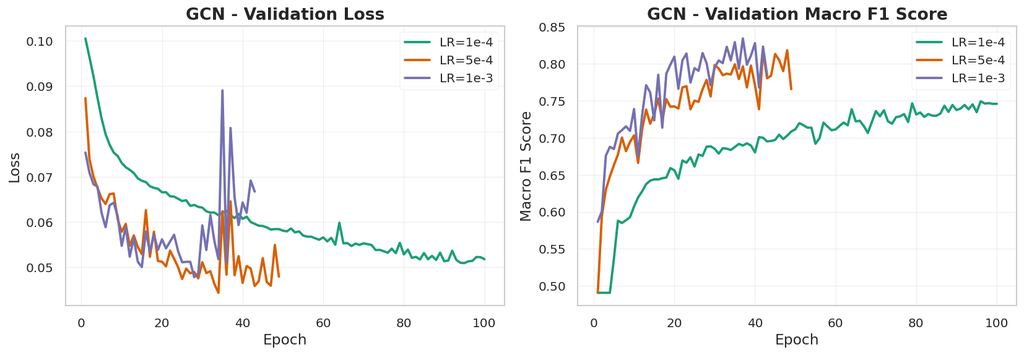

```python
# ============================================================================
# GCN: Plot Learning Rate Comparison (Validation Loss + Macro F1)
# ============================================================================

fig, (ax1, ax2) = plt.subplots(1, 2, figsize=(14, 5))

colors = ['#1b9e77', '#d95f02', '#7570b3']

# Plot Validation Loss
for (lr_label, history), color in zip(gcn_histories.items(), colors):
    epochs_range = range(1, len(history['val_loss']) + 1)
    ax1.plot(epochs_range, history['val_loss'], label=lr_label, linewidth=REPORT_PLOT_LINEWIDTH, color=color)

ax1.set_title('GCN - Validation Loss', fontsize=REPORT_PLOT_TITLE_SIZE, fontweight='bold')
ax1.set_xlabel('Epoch', fontsize=REPORT_PLOT_LABEL_SIZE)
ax1.set_ylabel('Loss', fontsize=REPORT_PLOT_LABEL_SIZE)
format_report_axes(ax1)
ax1.grid(alpha=0.3)

# Plot Validation Macro F1
for (lr_label, history), color in zip(gcn_histories.items(), colors):
    epochs_range = range(1, len(history['val_f1_macro']) + 1)
    ax2.plot(epochs_range, history['val_f1_macro'], label=lr_label, linewidth=REPORT_PLOT_LINEWIDTH, color=color)

ax2.set_title('GCN - Validation Macro F1 Score', fontsize=REPORT_PLOT_TITLE_SIZE, fontweight='bold')
ax2.set_xlabel('Epoch', fontsize=REPORT_PLOT_LABEL_SIZE)
ax2.set_ylabel('Macro F1 Score', fontsize=REPORT_PLOT_LABEL_SIZE)
format_report_axes(ax2)
ax2.grid(alpha=0.3)

plt.tight_layout()
save_plot(plt.gcf(), f"task4_gcn_lr_comparison", save_dir)
plt.show()
```

```python
# --- Evaluate GCN ---
for lr_label, model_gcn in gcn_models.items():
    print(f"\n{'='*60}")
    print(f"Evaluation for GCN - {lr_label}")
    print('='*60)

    y_val_true_gcn, y_val_pred_gcn = predict_loader_gnn(model_gcn, val_loader)
    print('\nValidation report (GCN):')
    print(classification_report(y_val_true_gcn, y_val_pred_gcn, digits=4, zero_division=0))

    y_test_true_gcn, y_test_pred_gcn = predict_loader_gnn(model_gcn, test_loader)
    print('Test report (GCN):')
    print(classification_report(y_test_true_gcn, y_test_pred_gcn, digits=4, zero_division=0))
```

```
============================================================
Evaluation for GCN - LR=1e-4
============================================================

Validation report (GCN):
              precision    recall  f1-score   support

           0     0.4009    0.7295    0.5174       122
           1     0.9892    0.9577    0.9732      3143

    accuracy                         0.9492      3265
   macro avg     0.6950    0.8436    0.7453      3265
weighted avg     0.9672    0.9492    0.9561      3265

Test report (GCN):
              precision    recall  f1-score   support

           0     0.3892    0.6502    0.4869       243
           1     0.9861    0.9604    0.9731      6262

    accuracy                         0.9488      6505
   macro avg     0.6876    0.8053    0.7300      6505
weighted avg     0.9638    0.9488    0.9549      6505


============================================================
Evaluation for GCN - LR=5e-4
============================================================

Validation report (GCN):
              precision    recall  f1-score   support

           0     0.4752    0.7869    0.5926       122
           1     0.9915    0.9663    0.9787      3143

    accuracy                         0.9596      3265
   macro avg     0.7334    0.8766    0.7857      3265
weighted avg     0.9722    0.9596    0.9643      3265

Test report (GCN):
```

[output cut: 18 more lines]

```
           1     0.9909    0.9723    0.9815      3143

    accuracy                         0.9648      3265
   macro avg     0.7551    0.8714    0.8010      3265
weighted avg     0.9733    0.9648    0.9680      3265

Test report (GCN):
              precision    recall  f1-score   support

           0     0.4788    0.6502    0.5515       243
           1     0.9862    0.9725    0.9793      6262

    accuracy                         0.9605      6505
   macro avg     0.7325    0.8114    0.7654      6505
weighted avg     0.9673    0.9605    0.9634      6505
```

```
Saved plot: /content/drive/MyDrive/Projects/AImSecure/Laboratory2/results/images/task4_plots/cm_gcn.png
```

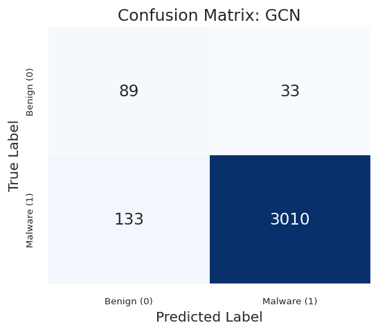

```
Saved plot: /content/drive/MyDrive/Projects/AImSecure/Laboratory2/results/images/task4_plots/cm_gcn.png
```

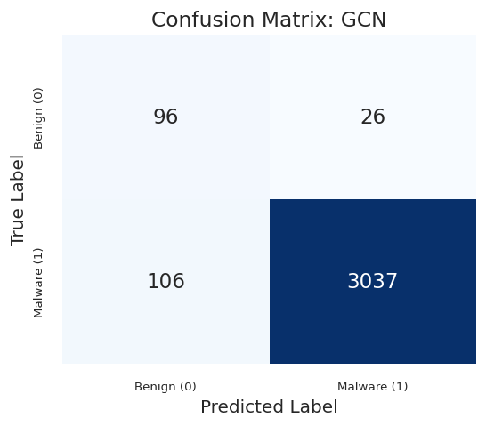

```
Saved plot: /content/drive/MyDrive/Projects/AImSecure/Laboratory2/results/images/task4_plots/cm_gcn.png
```

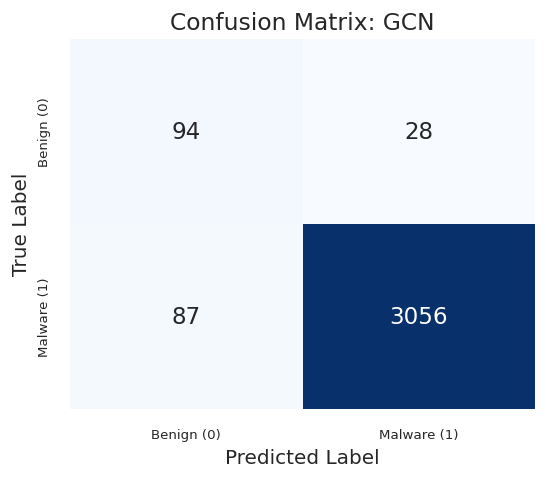

```python
for lr_label, model_gcn in gcn_models.items():
  plot_cm_task4(model=model_gcn,
                loader=val_loader,
                model_name="GCN",
                save_dir=results_path + 'images/task4_plots/')
```

```python
# ============================================================================
# GCN: Select Best Model and Evaluate
# ============================================================================

best_gcn_lr, model_gcn, history_gcn, elapsed_gcn, gcn_selection_table = select_best_gnn_model(
    architecture_name='GCN',
    models=gcn_models,
    histories=gcn_histories,
    elapsed_times=gcn_elapsed_times,
    val_loader=val_loader,
)

# Evaluate selected model
y_val_true_gcn, y_val_pred_gcn = predict_loader_gnn(model_gcn, val_loader)
print('\nValidation report (GCN):')
print(classification_report(y_val_true_gcn, y_val_pred_gcn, digits=4, zero_division=0))

y_test_true_gcn, y_test_pred_gcn = predict_loader_gnn(model_gcn, test_loader)
print('Test report (GCN):')
print(classification_report(y_test_true_gcn, y_test_pred_gcn, digits=4, zero_division=0))
```

```
Automatic selection for GCN
Ranking criterion: restored-model validation macro F1, then validation accuracy, then minimum validation loss
lr_label  last_history_val_f1_macro  val_accuracy  eval_val_f1_macro  min_val_loss  elapsed_s
 LR=1e-3                   0.784958      0.964778           0.800997      0.047833 146.011812
 LR=5e-4                   0.765904      0.959571           0.785661      0.044381 165.100300
 LR=1e-4                   0.746085      0.949158           0.745304      0.050943 338.551973

Selected best GCN model: LR=1e-3
Restored-model Val F1 Macro: 0.8010
Validation Accuracy: 0.9648

Validation report (GCN):
              precision    recall  f1-score   support

           0     0.5193    0.7705    0.6205       122
           1     0.9909    0.9723    0.9815      3143

    accuracy                         0.9648      3265
   macro avg     0.7551    0.8714    0.8010      3265
weighted avg     0.9733    0.9648    0.9680      3265

Test report (GCN):
              precision    recall  f1-score   support

           0     0.4788    0.6502    0.5515       243
           1     0.9862    0.9725    0.9793      6262

    accuracy                         0.9605      6505
   macro avg     0.7325    0.8114    0.7654      6505
weighted avg     0.9673    0.9605    0.9634      6505
```

#### 2. GraphSAGE

This model uses the GraphSAGE architecture

```python
# --- 2. GraphSAGE Model Definition ---

class GraphSAGEmodel(torch.nn.Module):
    def __init__(self, vocab_size, embed_dim, hidden_dim, output_dim):
        super(GraphSAGEmodel, self).__init__()

        self.embedding = nn.Embedding(vocab_size, embed_dim, padding_idx=0)

        # SAGEConv layers
        self.conv1 = SAGEConv(embed_dim, hidden_dim)
        self.conv2 = SAGEConv(hidden_dim, hidden_dim)
        self.conv3 = SAGEConv(hidden_dim, hidden_dim)

        self.pool = global_mean_pool # or global_max_pool

        self.classifier = nn.Sequential(
            nn.Linear(hidden_dim, hidden_dim),
            nn.ReLU(),
            nn.Dropout(0.5),
            nn.Linear(hidden_dim, output_dim)
        )

    def forward(self, data):
        x, edge_index, batch = data.x, data.edge_index, data.batch

        x = self.embedding(x.squeeze(1))

        x = self.conv1(x, edge_index)
        x = F.relu(x)
        x = F.dropout(x, p=0.2, training=self.training)

        x = self.conv2(x, edge_index)
        x = F.relu(x)
        x = F.dropout(x, p=0.2, training=self.training)

        x = self.conv3(x, edge_index)
        x = F.relu(x)
        x = F.dropout(x, p=0.2, training=self.training)

        x = self.pool(x, batch)
        out = self.classifier(x)
        return out
```

```python
# ============================================================================
# GraphSAGE: Training with Multiple Learning Rates
# ============================================================================

sage_learning_rates = [1e-4, 5e-4, 1e-3]
sage_lr_labels = ['LR=1e-4', 'LR=5e-4', 'LR=1e-3']

sage_histories = {}
sage_models = {}
sage_elapsed_times = {}

for lr, lr_label in zip(sage_learning_rates, sage_lr_labels):
    print(f"\n{'='*60}")
    print(f"Training GraphSAGE with {lr_label}")
    print('='*60)

    torch.manual_seed(42)
    np.random.seed(42)

    model_sage_temp = GraphSAGEmodel(
        vocab_size=VOCAB_SIZE_GNN,
        embed_dim=EMBED_DIM_GNN,
        hidden_dim=HIDDEN_DIM_GNN,
        output_dim=OUTPUT_DIM_GNN
    ).to(device)

    optimizer_temp = optim.AdamW(model_sage_temp.parameters(), lr=lr)

    model_sage_temp, history_temp, elapsed_temp = train_gnn_common(
        model_sage_temp,
        train_loader,
        val_loader,
        optimizer_temp,
        criterion_gnn,
        epochs=EPOCHS_GNN,
        min_delta=MIN_DELTA_GNN,
        patience=PATIENCE_GNN
    )

    sage_models[lr_label] = model_sage_temp
    sage_histories[lr_label] = history_temp
    sage_elapsed_times[lr_label] = elapsed_temp

    elapsed_str = time.strftime('%H:%M:%S', time.gmtime(elapsed_temp))
    print(f'\n{lr_label} - Training time: {elapsed_str}')
```

```
============================================================
Training GraphSAGE with LR=1e-4
============================================================

LR=1e-4 - Training time: 00:04:56

============================================================
Training GraphSAGE with LR=5e-4
============================================================
Early stopping at epoch 42 (best val loss 0.044889)

LR=5e-4 - Training time: 00:02:04

============================================================
Training GraphSAGE with LR=1e-3
============================================================
Early stopping at epoch 29 (best val loss 0.042609)

LR=1e-3 - Training time: 00:01:24
```

```
Saved plot: /content/drive/MyDrive/Projects/AImSecure/Laboratory2/results/images/task4_plots/task4_sage_lr_comparison.png.png
```

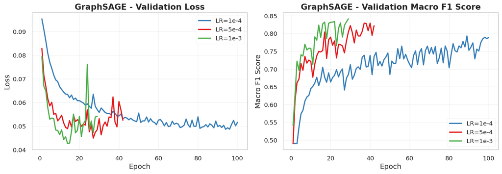

```python
# ============================================================================
# GraphSAGE: Plot Learning Rate Comparison
# ============================================================================

fig, (ax1, ax2) = plt.subplots(1, 2, figsize=(14, 5))

colors = ['#377eb8', '#e41a1c', '#4daf4a']

for (lr_label, history), color in zip(sage_histories.items(), colors):
    epochs_range = range(1, len(history['val_loss']) + 1)
    ax1.plot(epochs_range, history['val_loss'], label=lr_label, linewidth=REPORT_PLOT_LINEWIDTH, color=color)

ax1.set_title('GraphSAGE - Validation Loss', fontsize=REPORT_PLOT_TITLE_SIZE, fontweight='bold')
ax1.set_xlabel('Epoch', fontsize=REPORT_PLOT_LABEL_SIZE)
ax1.set_ylabel('Loss', fontsize=REPORT_PLOT_LABEL_SIZE)
format_report_axes(ax1)
ax1.grid(alpha=0.3)

for (lr_label, history), color in zip(sage_histories.items(), colors):
    epochs_range = range(1, len(history['val_f1_macro']) + 1)
    ax2.plot(epochs_range, history['val_f1_macro'], label=lr_label, linewidth=REPORT_PLOT_LINEWIDTH, color=color)

ax2.set_title('GraphSAGE - Validation Macro F1 Score', fontsize=REPORT_PLOT_TITLE_SIZE, fontweight='bold')
ax2.set_xlabel('Epoch', fontsize=REPORT_PLOT_LABEL_SIZE)
ax2.set_ylabel('Macro F1 Score', fontsize=REPORT_PLOT_LABEL_SIZE)
format_report_axes(ax2)
ax2.grid(alpha=0.3)

plt.tight_layout()
save_plot(plt.gcf(), f"task4_sage_lr_comparison.png", save_dir)
plt.show()
```

```
Saved plot: /content/drive/MyDrive/Projects/AImSecure/Laboratory2/results/images/task4_plots/graphsage_loss_curves_LR1e-4.png
```

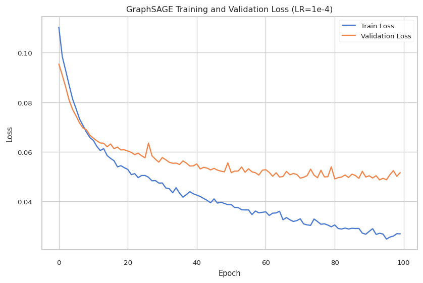

```
Saved plot: /content/drive/MyDrive/Projects/AImSecure/Laboratory2/results/images/task4_plots/graphsage_loss_curves_LR5e-4.png
```

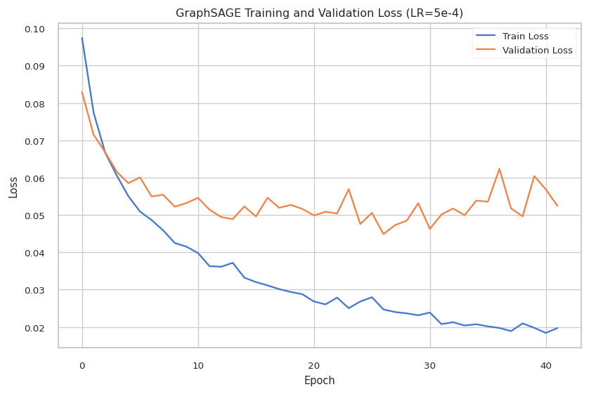

```
Saved plot: /content/drive/MyDrive/Projects/AImSecure/Laboratory2/results/images/task4_plots/graphsage_loss_curves_LR1e-3.png
```

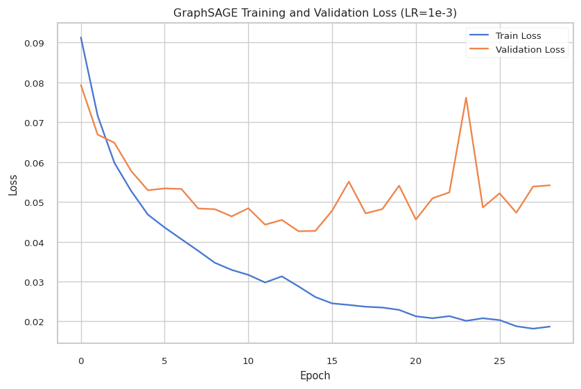

```python
for lr_label, model_sage in sage_models.items():
    history = sage_histories[lr_label]  # <-- Prendi la history per questo LR

    plt.figure(figsize=(8, 5))
    plt.plot(history['train_loss'], label='Train Loss')
    plt.plot(history['val_loss'], label='Validation Loss')
    plt.title(f'GraphSAGE Training and Validation Loss ({lr_label})')
    plt.xlabel('Epoch')
    plt.ylabel('Loss')
    plt.legend()
    plt.grid(True)
    save_plot(plt.gcf(), f'graphsage_loss_curves_{lr_label.replace("=", "")}', save_dir)
    plt.show()
```

```python
# --- Evaluate GraphSAGE ---
for lr_label, model_sage in sage_models.items():
  y_val_true_sage, y_val_pred_sage = predict_loader_gnn(model_sage, val_loader)
  print('\nValidation report (GraphSAGE):')
  print(classification_report(y_val_true_sage, y_val_pred_sage, digits=4, zero_division=0))

  y_test_true_sage, y_test_pred_sage = predict_loader_gnn(model_sage, test_loader)
  print('Test report (GraphSAGE):')
  print(classification_report(y_test_true_sage, y_test_pred_sage, digits=4, zero_division=0))
```

```
Validation report (GraphSAGE):
              precision    recall  f1-score   support

           0     0.4041    0.8115    0.5395       122
           1     0.9924    0.9535    0.9726      3143

    accuracy                         0.9482      3265
   macro avg     0.6982    0.8825    0.7560      3265
weighted avg     0.9704    0.9482    0.9564      3265

Test report (GraphSAGE):
              precision    recall  f1-score   support

           0     0.4311    0.7984    0.5599       243
           1     0.9919    0.9591    0.9752      6262

    accuracy                         0.9531      6505
   macro avg     0.7115    0.8787    0.7676      6505
weighted avg     0.9710    0.9531    0.9597      6505


Validation report (GraphSAGE):
              precision    recall  f1-score   support

           0     0.3817    0.8197    0.5208       122
           1     0.9927    0.9485    0.9701      3143

    accuracy                         0.9436      3265
   macro avg     0.6872    0.8841    0.7454      3265
weighted avg     0.9698    0.9436    0.9533      3265

Test report (GraphSAGE):
              precision    recall  f1-score   support

           0     0.4056    0.8395    0.5469       243
           1     0.9935    0.9523    0.9724      6262

    accuracy                         0.9480      6505
   macro avg     0.6995    0.8959    0.7597      6505
weighted avg     0.9715    0.9480    0.9565      6505


Validation report (GraphSAGE):
              precision    recall  f1-score   support

           0     0.6054    0.7295    0.6617       122
           1     0.9894    0.9815    0.9855      3143

    accuracy                         0.9721      3265
   macro avg     0.7974    0.8555    0.8236      3265
weighted avg     0.9751    0.9721    0.9734      3265

Test report (GraphSAGE):
              precision    recall  f1-score   support

           0     0.5813    0.6914    0.6316       243
           1     0.9879    0.9807    0.9843      6262

    accuracy                         0.9699      6505
   macro avg     0.7846    0.8360    0.8079      6505
weighted avg     0.9727    0.9699    0.9711      6505
```

```
Saved plot: /content/drive/MyDrive/Projects/AImSecure/Laboratory2/results/images/task4_plots/cm_graphsage.png
```

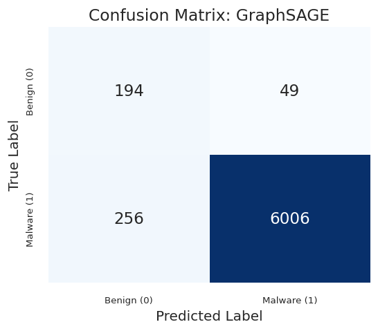

```
Saved plot: /content/drive/MyDrive/Projects/AImSecure/Laboratory2/results/images/task4_plots/cm_graphsage.png
```

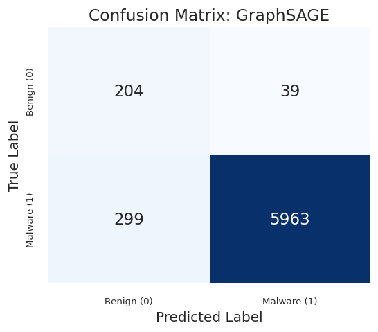

```
Saved plot: /content/drive/MyDrive/Projects/AImSecure/Laboratory2/results/images/task4_plots/cm_graphsage.png
```

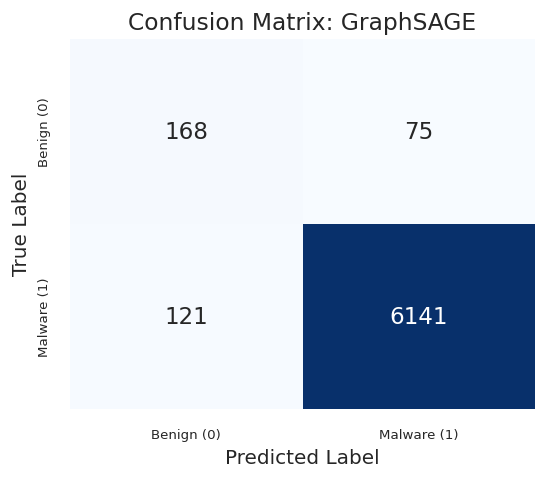

```python
for lr_label, model_sage in sage_models.items():
  plot_cm_task4(model=model_sage,
                loader=test_loader,
                model_name="GraphSAGE",
                save_dir=results_path + 'images/task4_plots/')
```

```python
# ============================================================================
# GraphSAGE: Select Best Model and Evaluate
# ============================================================================

best_sage_lr, model_sage, history_sage, elapsed_sage, sage_selection_table = select_best_gnn_model(
    architecture_name='GraphSAGE',
    models=sage_models,
    histories=sage_histories,
    elapsed_times=sage_elapsed_times,
    val_loader=val_loader,
)

y_val_true_sage, y_val_pred_sage = predict_loader_gnn(model_sage, val_loader)
print('\nValidation report (GraphSAGE):')
print(classification_report(y_val_true_sage, y_val_pred_sage, digits=4, zero_division=0))

y_test_true_sage, y_test_pred_sage = predict_loader_gnn(model_sage, test_loader)
print('Test report (GraphSAGE):')
print(classification_report(y_test_true_sage, y_test_pred_sage, digits=4, zero_division=0))
```

```
Automatic selection for GraphSAGE
Ranking criterion: restored-model validation macro F1, then validation accuracy, then minimum validation loss
lr_label  last_history_val_f1_macro  val_accuracy  eval_val_f1_macro  min_val_loss  elapsed_s
 LR=1e-3                   0.841225      0.972129           0.823588      0.042609  84.880655
 LR=1e-4                   0.788487      0.948239           0.756044      0.048644 296.050101
 LR=5e-4                   0.821914      0.943645           0.745448      0.044889 124.018934

Selected best GraphSAGE model: LR=1e-3
Restored-model Val F1 Macro: 0.8236
Validation Accuracy: 0.9721

Validation report (GraphSAGE):
              precision    recall  f1-score   support

           0     0.6054    0.7295    0.6617       122
           1     0.9894    0.9815    0.9855      3143

    accuracy                         0.9721      3265
   macro avg     0.7974    0.8555    0.8236      3265
weighted avg     0.9751    0.9721    0.9734      3265

Test report (GraphSAGE):
              precision    recall  f1-score   support

           0     0.5813    0.6914    0.6316       243
           1     0.9879    0.9807    0.9843      6262

    accuracy                         0.9699      6505
   macro avg     0.7846    0.8360    0.8079      6505
weighted avg     0.9727    0.9699    0.9711      6505
```

#### 3. GAT

This model uses the Graph Attention Network (GAT) architecture.

```python
class GATmodel(torch.nn.Module):
    def __init__(self, vocab_size, embed_dim, hidden_dim, output_dim, heads=4):
        super(GATmodel, self).__init__()

        self.embedding = nn.Embedding(vocab_size, embed_dim, padding_idx=0)

        # GAT Layers
        # Layer 1: Output is hidden_dim * heads
        self.conv1 = GATConv(embed_dim, hidden_dim, heads=heads, dropout=0.2)

        # Layer 2: Input is hidden_dim * heads. We set heads=1 for the final graph embedding before pooling.
        # concat=False means we average the heads or just output one head.
        self.conv2 = GATConv(hidden_dim * heads, hidden_dim, heads=1, concat=False, dropout=0.2)

        # Layer 3: Input should now be hidden_dim (output of conv2)
        self.conv3 = GATConv(hidden_dim, hidden_dim, heads=1, concat=False, dropout=0.2)

        self.pool = global_mean_pool

        self.classifier = nn.Sequential(
            nn.Linear(hidden_dim, hidden_dim),
            nn.ReLU(),
            nn.Linear(hidden_dim, output_dim)
        )

    def forward(self, data):
        x, edge_index, batch = data.x, data.edge_index, data.batch

        x = self.embedding(x.squeeze(1))

        # Conv 1
        x = self.conv1(x, edge_index)
        x = F.elu(x)

        # Conv 2
        x = self.conv2(x, edge_index)

        # Conv 3
        x = self.conv3(x, edge_index)

        # Pooling
        x = self.pool(x, batch)

        # Classifier
        out = self.classifier(x)
        return out
```

```python
# ============================================================================
# GAT: Training with Multiple Learning Rates
# ============================================================================

gat_learning_rates = [5e-5, 1e-4, 5e-4]
gat_lr_labels = ['LR=5e-5', 'LR=1e-4', 'LR=5e-4']

gat_histories = {}
gat_models = {}
gat_elapsed_times = {}

for lr, lr_label in zip(gat_learning_rates, gat_lr_labels):
    print(f"\n{'='*60}")
    print(f"Training GAT with {lr_label}")
    print('='*60)

    torch.manual_seed(42)
    np.random.seed(42)

    model_gat_temp = GATmodel(
        vocab_size=VOCAB_SIZE_GNN,
        embed_dim=EMBED_DIM_GNN,
        hidden_dim=HIDDEN_DIM_GNN,
        output_dim=OUTPUT_DIM_GNN,
        heads=4
    ).to(device)

    optimizer_temp = optim.AdamW(model_gat_temp.parameters(), lr=lr)

    model_gat_temp, history_temp, elapsed_temp = train_gnn_common(
        model_gat_temp,
        train_loader,
        val_loader,
        optimizer_temp,
        criterion_gnn,
        epochs=EPOCHS_GNN,
        min_delta=MIN_DELTA_GNN,
        patience=PATIENCE_GNN
    )

    gat_models[lr_label] = model_gat_temp
    gat_histories[lr_label] = history_temp
    gat_elapsed_times[lr_label] = elapsed_temp

    elapsed_str = time.strftime('%H:%M:%S', time.gmtime(elapsed_temp))
    print(f'\n{lr_label} - Training time: {elapsed_str}')
```

```
============================================================
Training GAT with LR=5e-5
============================================================

LR=5e-5 - Training time: 00:07:29

============================================================
Training GAT with LR=1e-4
============================================================
Early stopping at epoch 87 (best val loss 0.041429)

LR=1e-4 - Training time: 00:06:33

============================================================
Training GAT with LR=5e-4
============================================================
Early stopping at epoch 71 (best val loss 0.035316)

LR=5e-4 - Training time: 00:05:22
```

```
Saved plot: /content/drive/MyDrive/Projects/AImSecure/Laboratory2/results/images/task4_plots/task4_gat_lr_comparison.png.png
```

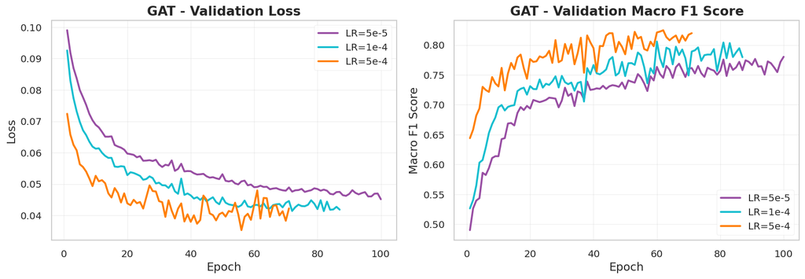

```python
# ============================================================================
# GAT: Plot Learning Rate Comparison
# ============================================================================

fig, (ax1, ax2) = plt.subplots(1, 2, figsize=(14, 5))

colors = ['#984ea3', '#17becf', '#ff7f00']

for (lr_label, history), color in zip(gat_histories.items(), colors):
    epochs_range = range(1, len(history['val_loss']) + 1)
    ax1.plot(epochs_range, history['val_loss'], label=lr_label, linewidth=REPORT_PLOT_LINEWIDTH, color=color)

ax1.set_title('GAT - Validation Loss', fontsize=REPORT_PLOT_TITLE_SIZE, fontweight='bold')
ax1.set_xlabel('Epoch', fontsize=REPORT_PLOT_LABEL_SIZE)
ax1.set_ylabel('Loss', fontsize=REPORT_PLOT_LABEL_SIZE)
format_report_axes(ax1)
ax1.grid(alpha=0.3)

for (lr_label, history), color in zip(gat_histories.items(), colors):
    epochs_range = range(1, len(history['val_f1_macro']) + 1)
    ax2.plot(epochs_range, history['val_f1_macro'], label=lr_label, linewidth=REPORT_PLOT_LINEWIDTH, color=color)

ax2.set_title('GAT - Validation Macro F1 Score', fontsize=REPORT_PLOT_TITLE_SIZE, fontweight='bold')
ax2.set_xlabel('Epoch', fontsize=REPORT_PLOT_LABEL_SIZE)
ax2.set_ylabel('Macro F1 Score', fontsize=REPORT_PLOT_LABEL_SIZE)
format_report_axes(ax2)
ax2.grid(alpha=0.3)

plt.tight_layout()
save_plot(plt.gcf(), f"task4_gat_lr_comparison.png", save_dir)
plt.show()
```

```
Saved plot: /content/drive/MyDrive/Projects/AImSecure/Laboratory2/results/images/task4_plots/graphgat_loss_curves_LR5e-5.png
```

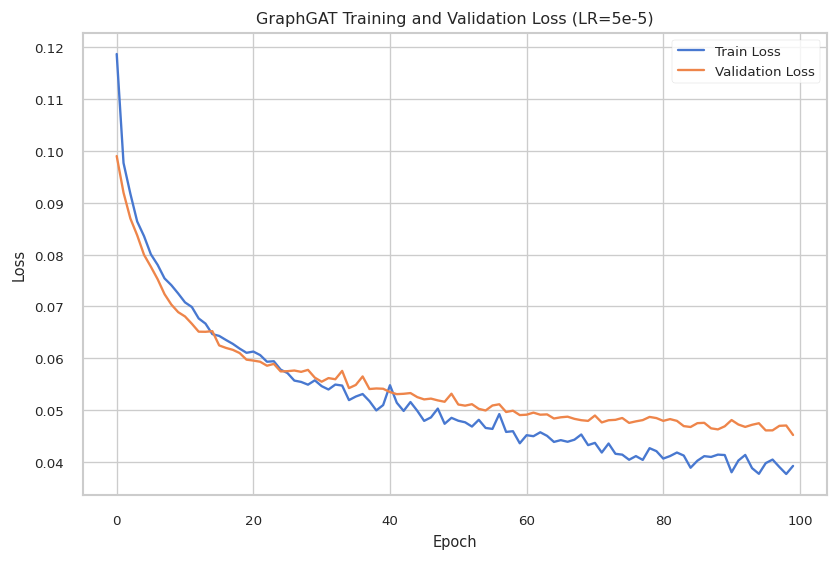

```
Saved plot: /content/drive/MyDrive/Projects/AImSecure/Laboratory2/results/images/task4_plots/graphgat_loss_curves_LR1e-4.png
```

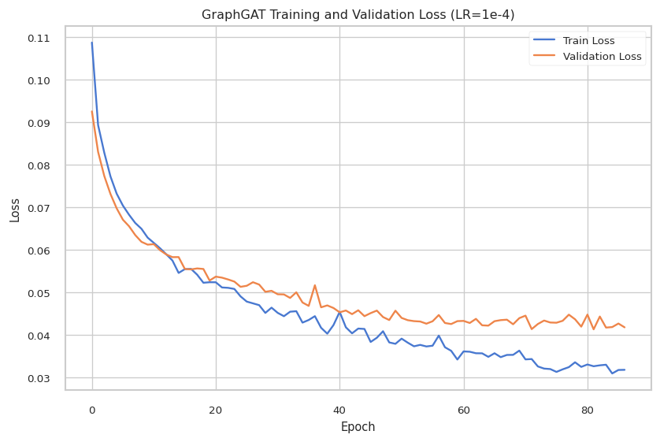

```
Saved plot: /content/drive/MyDrive/Projects/AImSecure/Laboratory2/results/images/task4_plots/graphgat_loss_curves_LR5e-4.png
```

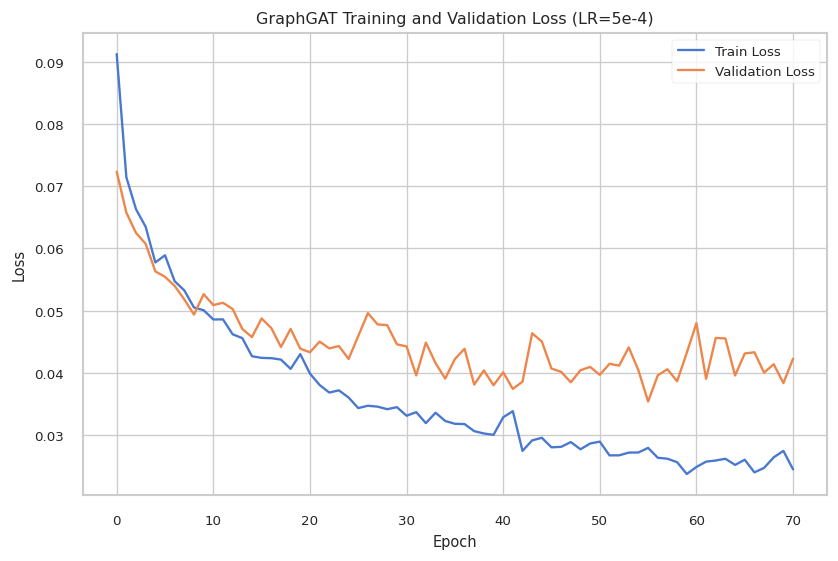

```python
for lr_label, model_gat in gat_models.items():
    history = gat_histories[lr_label]  # <-- Prendi la history per questo LR

    plt.figure(figsize=(8, 5))
    plt.plot(history['train_loss'], label='Train Loss')
    plt.plot(history['val_loss'], label='Validation Loss')
    plt.title(f'GraphGAT Training and Validation Loss ({lr_label})')
    plt.xlabel('Epoch')
    plt.ylabel('Loss')
    plt.legend()
    plt.grid(True)
    save_plot(plt.gcf(), f'graphgat_loss_curves_{lr_label.replace("=", "")}', save_dir)
    plt.show()
```

```python
# --- Evaluate GAT ---
for lr_label, model_gat in gat_models.items():
  y_val_true_gat, y_val_pred_gat = predict_loader_gnn(model_gat, val_loader)
  print('\nValidation report (GAT):')
  print(classification_report(y_val_true_gat, y_val_pred_gat, digits=4, zero_division=0))

  y_test_true_gat, y_test_pred_gat = predict_loader_gnn(model_gat, test_loader)
  print('Test report (GAT):')
  print(classification_report(y_test_true_gat, y_test_pred_gat, digits=4, zero_division=0))
```

```
Validation report (GAT):
              precision    recall  f1-score   support

           0     0.5093    0.6721    0.5795       122
           1     0.9871    0.9749    0.9810      3143

    accuracy                         0.9636      3265
   macro avg     0.7482    0.8235    0.7802      3265
weighted avg     0.9693    0.9636    0.9660      3265

Test report (GAT):
              precision    recall  f1-score   support

           0     0.5079    0.6626    0.5750       243
           1     0.9867    0.9751    0.9809      6262

    accuracy                         0.9634      6505
   macro avg     0.7473    0.8188    0.7779      6505
weighted avg     0.9689    0.9634    0.9657      6505


Validation report (GAT):
              precision    recall  f1-score   support

           0     0.5316    0.6885    0.6000       122
           1     0.9878    0.9765    0.9821      3143

    accuracy                         0.9657      3265
   macro avg     0.7597    0.8325    0.7910      3265
weighted avg     0.9707    0.9657    0.9678      3265

Test report (GAT):
              precision    recall  f1-score   support

           0     0.5503    0.7202    0.6239       243
           1     0.9890    0.9772    0.9831      6262

    accuracy                         0.9676      6505
   macro avg     0.7697    0.8487    0.8035      6505
weighted avg     0.9726    0.9676    0.9696      6505


Validation report (GAT):
              precision    recall  f1-score   support

           0     0.4876    0.8033    0.6068       122
           1     0.9922    0.9672    0.9795      3143

    accuracy                         0.9611      3265
   macro avg     0.7399    0.8853    0.7932      3265
weighted avg     0.9733    0.9611    0.9656      3265

Test report (GAT):
              precision    recall  f1-score   support

           0     0.5125    0.7572    0.6113       243
           1     0.9904    0.9721    0.9811      6262

    accuracy                         0.9640      6505
   macro avg     0.7515    0.8646    0.7962      6505
weighted avg     0.9725    0.9640    0.9673      6505
```

```
Saved plot: /content/drive/MyDrive/Projects/AImSecure/Laboratory2/results/images/task4_plots/cm_gat.png
```

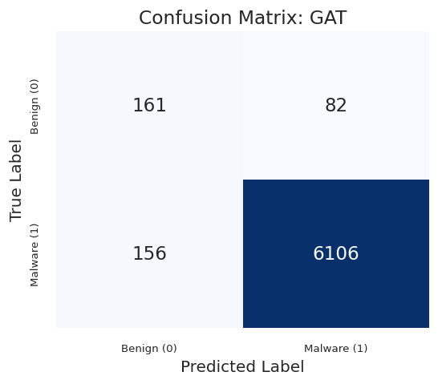

```
Saved plot: /content/drive/MyDrive/Projects/AImSecure/Laboratory2/results/images/task4_plots/cm_gat.png
```

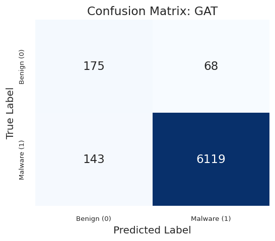

```
Saved plot: /content/drive/MyDrive/Projects/AImSecure/Laboratory2/results/images/task4_plots/cm_gat.png
```

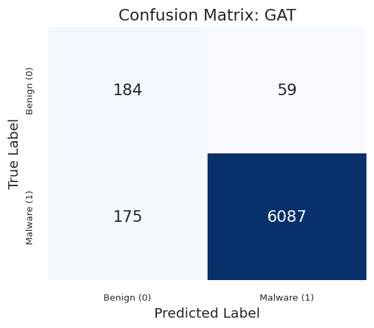

```python
for lr_label, model_gat in gat_models.items():
    plot_cm_task4(model=model_gat,
                  loader=test_loader,
                  model_name="GAT",
                  save_dir=results_path + 'images/task4_plots/')
```

```python
# ============================================================================
# GAT: Select Best Model and Evaluate
# ============================================================================

best_gat_lr, model_gat, history_gat, elapsed_gat, gat_selection_table = select_best_gnn_model(
    architecture_name='GAT',
    models=gat_models,
    histories=gat_histories,
    elapsed_times=gat_elapsed_times,
    val_loader=val_loader,
)

y_val_true_gat, y_val_pred_gat = predict_loader_gnn(model_gat, val_loader)
print('\nValidation report (GAT):')
print(classification_report(y_val_true_gat, y_val_pred_gat, digits=4, zero_division=0))

y_test_true_gat, y_test_pred_gat = predict_loader_gnn(model_gat, test_loader)
print('Test report (GAT):')
print(classification_report(y_test_true_gat, y_test_pred_gat, digits=4, zero_division=0))
```

```
Automatic selection for GAT
Ranking criterion: restored-model validation macro F1, then validation accuracy, then minimum validation loss
lr_label  last_history_val_f1_macro  val_accuracy  eval_val_f1_macro  min_val_loss  elapsed_s
 LR=5e-4                   0.819724      0.961103           0.793175      0.035316 322.178674
 LR=1e-4                   0.779538      0.965697           0.791040      0.041377 393.894694
 LR=5e-5                   0.780228      0.963553           0.780228      0.045157 449.578457

Selected best GAT model: LR=5e-4
Restored-model Val F1 Macro: 0.7932
Validation Accuracy: 0.9611

Validation report (GAT):
              precision    recall  f1-score   support

           0     0.4876    0.8033    0.6068       122
           1     0.9922    0.9672    0.9795      3143

    accuracy                         0.9611      3265
   macro avg     0.7399    0.8853    0.7932      3265
weighted avg     0.9733    0.9611    0.9656      3265

Test report (GAT):
              precision    recall  f1-score   support

           0     0.5125    0.7572    0.6113       243
           1     0.9904    0.9721    0.9811      6262

    accuracy                         0.9640      6505
   macro avg     0.7515    0.8646    0.7962      6505
weighted avg     0.9725    0.9640    0.9673      6505
```

```
Saved plot: /content/drive/MyDrive/Projects/AImSecure/Laboratory2/results/images/task4_plots/task4_gnn_comparison_f1_macro.png
```

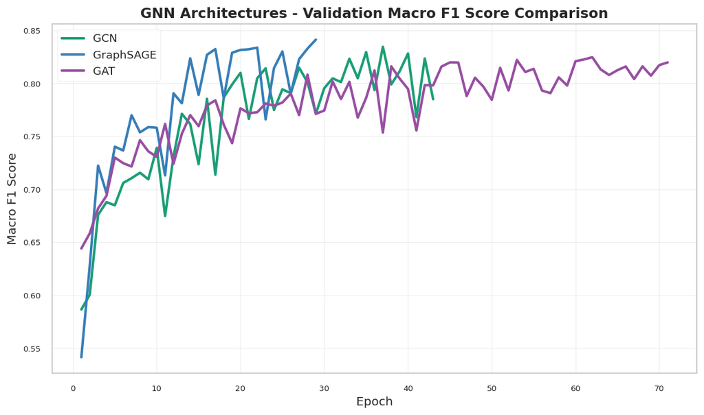

```python
# ============================================================================
# GNN Comparison: Validation Macro F1 Score (Best LR for each model)
# ============================================================================

fig, ax = plt.subplots(figsize=(10, 6))

# Plot best model for each architecture
best_models_gnn = {
    'GCN': history_gcn,
    'GraphSAGE': history_sage,
    'GAT': history_gat
}

colors_gnn = ['#1b9e77', '#377eb8', '#984ea3']

for (name, history), color in zip(best_models_gnn.items(), colors_gnn):
    epochs_range = range(1, len(history['val_f1_macro']) + 1)
    ax.plot(epochs_range, history['val_f1_macro'], label=name, linewidth=2.5, color=color)

ax.set_title('GNN Architectures - Validation Macro F1 Score Comparison', fontsize=14, fontweight='bold')
ax.set_xlabel('Epoch', fontsize=12)
ax.set_ylabel('Macro F1 Score', fontsize=12)
ax.legend(fontsize=11)
ax.grid(alpha=0.3)

plt.tight_layout()
save_plot(plt.gcf(), f"task4_gnn_comparison_f1_macro", save_dir)
plt.show()
```

```python
# ============================================================================
# FINAL REPORT: GNN Architecture Comparison
# ============================================================================

def get_test_metrics(y_true, y_pred):
    """Extract test metrics from predictions."""
    report = classification_report(y_true, y_pred, output_dict=True, zero_division=0)
    return {
        'precision': report['macro avg']['precision'],
        'recall': report['macro avg']['recall'],
        'f1_score': report['macro avg']['f1-score'],
        'accuracy': report['accuracy'],
        'benign_recall': report['0']['recall'],
        'malware_recall': report['1']['recall'],
    }

metrics_gcn = get_test_metrics(y_test_true_gcn, y_test_pred_gcn)
metrics_sage = get_test_metrics(y_test_true_sage, y_test_pred_sage)
metrics_gat = get_test_metrics(y_test_true_gat, y_test_pred_gat)

gnn_summary = pd.DataFrame([
    {
        'architecture': 'GCN',
        'selected_lr': best_gcn_lr,
        'val_macro_f1': gcn_selection_table.loc[0, 'eval_val_f1_macro'],
        'test_macro_f1': metrics_gcn['f1_score'],
        'test_accuracy': metrics_gcn['accuracy'],
        'test_benign_recall': metrics_gcn['benign_recall'],
        'test_malware_recall': metrics_gcn['malware_recall'],
        'training_time_s': elapsed_gcn,
    },
    {
        'architecture': 'GraphSAGE',
        'selected_lr': best_sage_lr,
        'val_macro_f1': sage_selection_table.loc[0, 'eval_val_f1_macro'],
        'test_macro_f1': metrics_sage['f1_score'],
        'test_accuracy': metrics_sage['accuracy'],
        'test_benign_recall': metrics_sage['benign_recall'],
        'test_malware_recall': metrics_sage['malware_recall'],
        'training_time_s': elapsed_sage,
    },
    {
        'architecture': 'GAT',
        'selected_lr': best_gat_lr,
        'val_macro_f1': gat_selection_table.loc[0, 'eval_val_f1_macro'],
        'test_macro_f1': metrics_gat['f1_score'],
        'test_accuracy': metrics_gat['accuracy'],
        'test_benign_recall': metrics_gat['benign_recall'],
        'test_malware_recall': metrics_gat['malware_recall'],
        'training_time_s': elapsed_gat,
    },
])

gnn_summary = gnn_summary.sort_values(
    by=['test_macro_f1', 'test_accuracy', 'test_benign_recall'],
    ascending=[False, False, False]
).reset_index(drop=True)

best_gnn_row = gnn_summary.iloc[0]

print("\n" + "="*120)
print("FINAL REPORT: GNN Architecture Comparison (Test Set)")
print("Ranking criterion: test macro F1, then test accuracy, then benign recall")
print("="*120)
display(gnn_summary)
print(
    f"Best-performing GNN on the test set: {best_gnn_row['architecture']} "
    f"({best_gnn_row['selected_lr']}) | "
    f"test macro F1={best_gnn_row['test_macro_f1']:.4f}, "
    f"accuracy={best_gnn_row['test_accuracy']:.4f}, "
    f"benign recall={best_gnn_row['test_benign_recall']:.4f}"
)
```

```
========================================================================================================================
FINAL REPORT: GNN Architecture Comparison (Test Set)
Ranking criterion: test macro F1, then test accuracy, then benign recall
========================================================================================================================
```

|  | architecture | selected_lr | val_macro_f1 | test_macro_f1 | test_accuracy | test_benign_recall | test_malware_recall | training_time_s |
| --- | --- | --- | --- | --- | --- | --- | --- | --- |
| 0 | GraphSAGE | LR=1e-3 | 0.823588 | 0.807936 | 0.969869 | 0.691358 | 0.980677 | 84.880655 |
| 1 | GAT | LR=5e-4 | 0.793175 | 0.796218 | 0.964028 | 0.757202 | 0.972054 | 322.178674 |
| 2 | GCN | LR=1e-3 | 0.800997 | 0.765410 | 0.960492 | 0.650206 | 0.972533 | 146.011812 |

```
Best-performing GNN on the test set: GraphSAGE (LR=1e-3) | test macro F1=0.8079, accuracy=0.9699, benign recall=0.6914
```

#### Q: How does each model perform compared to the previous architectures? Can you beat the baseline?

Yes, the graph models beat the frequency baseline in macro F1, although the baseline remains very competitive in accuracy. The baseline reaches test accuracy `96.97%` and macro F1 `0.7223`, but its benign recall is only `0.3457`. This confirms that accuracy alone is misleading on this imbalanced dataset.

Among the GNNs, GraphSAGE is the strongest selected architecture in this run. It selects `LR=1e-3` and reaches test macro F1 `0.8079`, accuracy `96.99%`, and benign recall `0.6914`. GAT selects `LR=5e-4` and obtains test macro F1 `0.7962`, while GCN selects `LR=1e-3` and obtains test macro F1 `0.7654`. All three GNNs improve benign recall with respect to the frequency baseline, while keeping high malware recall.

Compared with the previous architectures, FFNNs remain the weakest family: even with learnable embeddings and embedding-size tuning, the best FFNN test macro F1 is around `0.59`, mainly because the model relies on fixed-length truncation and cannot explicitly model temporal or structural dependencies. RNNs improve substantially: the selected bidirectional LSTM reaches test macro F1 `0.8305`, making it the best overall model in this run. GNNs are slightly below the Bi-LSTM, but clearly stronger than FFNNs and the frequency baseline in terms of balanced classification.

Overall, the experiments show that both sequential information and transition-graph structure are useful. The frequency baseline is strong because API-call counts are informative, but RNNs and GNNs provide a better balance between malware detection and benign recognition.